# Cardiac Pathology Prediction - IMA 205 Challenge

### Projet Kaggle - Rapport détaillé

Réalisé par **Maël Le Guillouzic** (Bastaxeloux on Kaggle) – 2025

## 1. Abstract

Ce rapport décrit l'intégralité de mon approche au challenge d'IMA-205 2025 : Classification de pathologies cardiaques. Le but était d'attribuer à chaque patient d'un ensemble test une pathologie, et ce en utilisant uniquement des masques de segmentation fournis à deux instants du cycle cardiaque.

Sur un dataset équilibré mais de très petite taille, mon approche en deux temps à permis d'aboutir à 93% d'accuracy. Ce projet permet nottament de se rendre compte que sur de telles data, une approche rigoureuse de feature engineering, suivi d'un modèle simple d'apprentissage supervisé, peuvent surpasser des modèles bien plus lourds et à l'aspect bien plus "boite noire" tout en apportant une plus grande vitesse d'éxecution et une "explainibility" accrue.

## 2. Introduction

### 2.1 Le Dataset

#### 2.1.1 Le jeu de données ACDC

Pour notre projet, nous utilisons le jeu de données fournis pour le challenge, basé sur le dataset ACDC (Automatic Cardiac Diagnosis Challenge) élaboré en 2017 à l’Hopital de Dijon dans le cadre d’un challenge de segmentation. Ce dernier qui offre un ensemble standardisé d’images 3D+T, ainsi que des masques de segmentations qui nous seront utiles pour établir les features sur lesquelles on entrainera nos modèles.

La données se structure ainsi de la manière suivante :

- 100 patients pour le train
- 50 patients de test divisés en deux catégories
  - 1/3 (environ 17 patients) utilisé pour établir le leaderboard public. C'est, avec les accuracy sur le jeu de train, la seule mesure de performance dont nous disposions tout au long du challenge
  - 2/3 (environ 33 patients) utilisés pour le leaderboard privé. Ce dernier fut révélé à la fin du challenge. Il servira à établir la performance "réelle" de nos méthodes, sans biais d'entrainement. C'est un point très important de toute méthode scientifique rigoureuse, et c'est pourquoi l'intégralité des méthodes proposées dans ce rapport n'ont pas étés changées depuis la révélation du leaderboard privé.

#### 2.1.2 Contenu d'un patient

Pour chaque patient, on dispose :

- De deux images IRM (donc 3D) à deux instants précis du cycle cardiaque : la diastole qui correspond à la fin de la phase de dilation, et à la systole (fin de la contraction).
- D’une segmentation, de trois structures anatomiques d'intêret :
  - Ventricule Droit
  - Ventricule Gauche
  - Myocarde
- D'un fichier texte `métadata`, contenant le poids, la taille, et la catégorie cible de chaque patient.

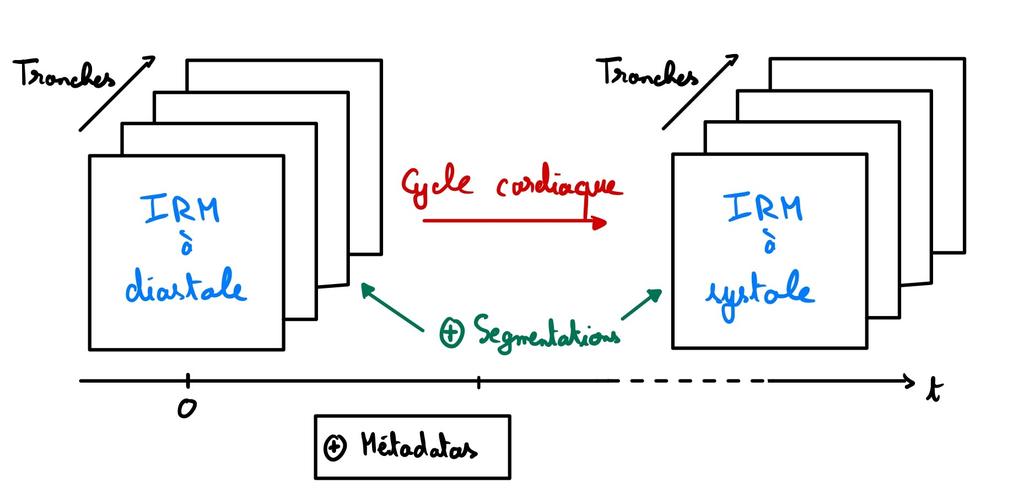

```python
from IPython.display import Image, display
display(Image(filename='dataset.jpg', width=800))
```

Observons un patient. Pour cela nous importons les bibliothèques nécessaires; nous utiliserons `torchio` pour visualiser nos images, et `LabelMap` pour les segmentations.

```python
import os
import numpy as np
import matplotlib.pyplot as plt
from matplotlib.colors import ListedColormap
import torchio as tio
from IPython.display import display, clear_output
from ipywidgets import interact, IntSlider
import SimpleITK as sitk
sitk.ProcessObject_SetGlobalWarningDisplay(False)

import pandas as pd
from scipy.ndimage import binary_fill_holes
from tqdm import tqdm
import itertools
```

On peut désormais charger les données des 100 patients de la partie Train du Dataset. La fonction `load()` charge les images 3D, et retournes 3 objets importants pour la suite :

- **image.data.squeeze().numpy()** .numpy => convertit le tenseur en tableau numpy et .squeeze => enlève les dimensions de taille 1
- **image.affine** => matrice de transformation affine. C'est à dire que si on dispose des coordonnées en mm on peut les transformer en coordonnées de pixels en multipliant par cette matrice
- **image.spacing** => taille des pixels en mm. Cela sera particulièrement utile

```python
n_patient = 87
if 0 < n_patient < 10:
    n_patient = "00" + str(n_patient)
elif 9 < n_patient < 100:
    n_patient = "0" + str(n_patient)
ed_path = f"Dataset/Train/{n_patient}/{n_patient}_ED.nii"
es_path = f"Dataset/Train/{n_patient}/{n_patient}_ES.nii"
ed_seg_path = f"Dataset/Train/{n_patient}/{n_patient}_ED_seg.nii"
es_seg_path = f"Dataset/Train/{n_patient}/{n_patient}_ES_seg.nii"

for path in [ed_path, es_path, ed_seg_path, es_seg_path]:
    if not os.path.exists(path):
        raise FileNotFoundError(f"File {path} does not exist.")

# on a les chemin, chargeons désormais les images
def load(path, verbose=False):
    image = tio.ScalarImage(path)
    if verbose:
        print(f"Taille de l'objet image chargé : {image.shape}")
    return image.data.squeeze().numpy(), image.affine, image.spacing
# les trois objets retournés vont être important dans la suite du projet
# # .data => extrait l'image de l'objet chargé, .numpy => convertit le tenseur en tableau numpy et .squeeze => enlève les dimensions de taille 1
# .affine => matrice de transformation affine, donc en gros si on a des coordonnées en mm on peut les transformer en coordonnées de pixels en multipliant par cette matrice
# .spacing => taille des pixels en mm


# chargeons ensuite les segmentations
def load_seg(path, verbose=False):
    segmentation = tio.LabelMap(path)
    if verbose:
        print(f"Taille de l'objet segmentation chargé : {segmentation.shape}")
        print(f"Nombre de pixels par classe : {np.unique(segmentation.numpy(), return_counts=True)}")
    return segmentation.data.squeeze().numpy(), segmentation.affine, segmentation.spacing

load_ed, affine_ed, spacing_ed = load(ed_path, verbose=True)
load_es, affine_es, spacing_es = load(es_path, verbose=True)
load_ed_seg, affine_ed_seg, spacing_ed_seg = load_seg(ed_seg_path, verbose=True)
load_es_seg, affine_es_seg, spacing_es_seg = load_seg(es_seg_path, verbose=True)
```

```
Taille de l'objet image chargé : (1, 256, 184, 8)
Taille de l'objet image chargé : (1, 256, 184, 8)
Taille de l'objet segmentation chargé : (1, 256, 184, 8)
Nombre de pixels par classe : (array([0, 1, 2, 3], dtype=uint8), array([351286,  12060,   5255,   8231]))
Taille de l'objet segmentation chargé : (1, 256, 184, 8)
Nombre de pixels par classe : (array([0, 1, 2, 3], dtype=uint8), array([356316,   8966,   7138,   4412]))
```

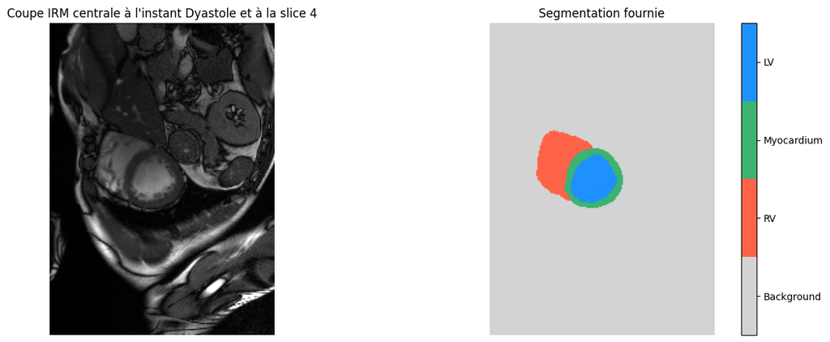

```python
def affichage_simple(image, seg, slice=None):
    if slice is None:
        slice = image.shape[2] // 2
    fig,ax = plt.subplots(1,2,figsize=(14,5))
    ax.flatten
    colors = ['lightgray', '#FF6347', '#3CB371', '#1E90FF'] # Tomato Red, Medium Sea Green, Dodger Blue
    cmap = ListedColormap(colors)
    ax[0].imshow(image[:,:,slice], cmap='gray')
    ax[0].set_title("Coupe IRM centrale à l'instant Dyastole et à la slice " + str(slice))
    ax[0].axis('off')
    im_seg = ax[1].imshow(seg[:,:,slice], cmap=cmap, vmin=0, vmax=len(colors)-1)
    ax[1].set_title(f"Segmentation fournie")
    ax[1].axis('off')
    cbar = fig.colorbar(im_seg, ax=ax[1], ticks=[0.375, 1.125, 1.875, 2.625])
    cbar.ax.set_yticklabels(['Background', 'RV', 'Myocardium', 'LV'])
    plt.tight_layout()
    plt.show()

affichage_simple(load_ed,load_ed_seg)
```

Ci dessous voici un exemple des métadata du patient affiché ci dessus.

| Id | Category | Height | Weight |
| --- | --- | --- | --- |
| 087 | 4 | 170.0 | 64.0 |

Enfin, on les décrira plus en détail ci dessous, mais les 5 classes du datasets sont présentes de manière parfaitement équilibrée. On a ainsi dans les deux parties du dataset :

- 20 patients par classe sur le train
- 10 sur le test

On pense ainsi tout de suite qu'a priori un ré-équilibrage des classes ne sera pas nécessaire.

### 2.2 Objectif du challenge

Le but du challenge est simple : à partir des informations décrites ci dessous dont nous disposons, assigner à chaque patient une des cinq pathologies suivantes :

- Healthy controls (NOR)
- Myocardial infarction (MINF)
- Dilated cardiomyopathy (DCM)
- Hypertrophic cardiomyopathy (HCM)
- Abnormal right ventricle (RVA)

Le papier `Deep Learning Techniques for Automatic MRI [...] Diagnosis` nous informe un peu plus sur les signes cliniques de chaque pathologie et les crières utilisés aujourd'hui pour alarmer un médecin sur un cas clinique. Commencer par une étude rapide de ces critères pourra nous guider dans l'élaboration de nos features.

Ainsi, l'hopital de Dijon qui à élaboré le dataset, donne les critères suivants :

- NOR : Fraction d'éjection > 50%. Wall thickness < 12mm. LV diastolic volume < 90 mL/m2 (hommes) and 80 mL/m2 (femmes). RV normal pour tous les patients (RV volume < 100 mL/m2 et RV ejection fraction > 40%).
- MINF : Fraction d'éjection < 40% et contractions myocardiales anormales. Gros volume diastolique du LV.
- DCM : Fraction d'éjection < 40%. LV volume > than 100 mL/m2 et wall thickness en diastole < 12 mm. Dilated RV.
- HCM : Fraction d'éjection > 55%. Epaisseur de la myocarde supérieure à 15 mm en diastole.
- RVA : RV volume > 110 mL/m2 pour les hommes (100 mL/m2 pour les femmes), et/ou RV ejection fraction < 40%. Quasiment tous les patients ont un ventricule gauche normal.

Ce que nous remarquons dans un premier temps, c'est que la quasi totalités des critères médicaux se basent sur les volumes des 3 structures d'intéret fournies. Celles sur le poids sont similaires au volume, à un simple rapport de masse volumique près. De plus il est très souvent mentionné des rapport entre volume, on peut s'attendre à ce que les features de ce type soient très utiles lors de notre apprentissage.

### 2.3 Segmentation du ventricule gauche manquante

Afin d'avoir une meilleur idée de la plausibilité de la data fournie, de son allure, et de sa qualité , on implémente une petite fonction `slider` qui permet dans un jupyter notebook de défiler simplement entre les slides d'une image et leur segmentation, et qu'on peut adapter pour visualiser tous les patients.

On remarque alors un point important : sur le Dataset Test, la segmentation du ventricule gauche n'est pas fournie (comme précisé dans les consignes du challenge).

```python
def affichage_slider(image,seg):
    slide_max = image.shape[2] - 1 # pour savoir jusqu'ou le slider ira
    def update(slice): # a chaque appel de update, on actualise l'affichage
        affichage_simple(image,seg,slice)
    slider = IntSlider(min=0, max=slide_max, step=1, value=slide_max//2) # on initialise le slider
    interact(update, slice=slider) # en un appel on a un slider avec toutes les slides

affichage_slider(load_ed, load_ed_seg)
```

```
interactive(children=(IntSlider(value=3, description='slice', max=7), Output()), _dom_classes=('widget-interac…
```

Néanmoins on remarque aussi un détail important, sur la totalité des images et la quasi totalité des slides, cette partie non segmentée est completement entourée par la myocarde. On choisit alors la solution la plus simple : pour chaque image le ventricule gauche sera défini comme étant l'intérieur de cette segmentation fermée de la myocarde.

Remarque : Mon projet du P1 consistait justement à segmenter ce ventricule gauche. Ayant déja réalisé l'exercice, c'est pour cela que je ne m'y suis pas attardé afin de travailler sur le reste du challenge.

Voici ci dessous la fonction `fill_LV_test_2D` qui complète l'intérieur de la myocarde pour définir le LV.

On définit aussi une fonction d'affichage avant-après pour visualiser le résultat.

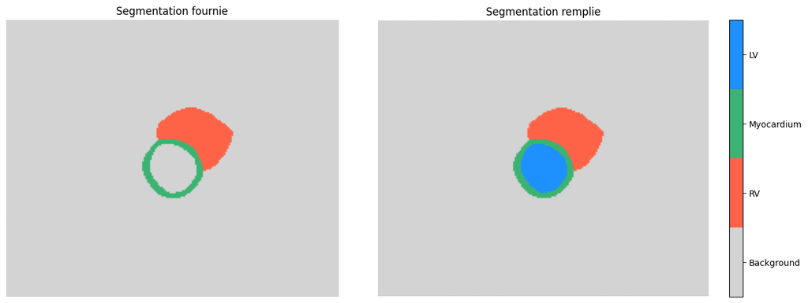

```python
def fill_LV_test_2D(segmentation, label=2):
    masque = (segmentation == label)
    masque_rempli = np.zeros_like(masque)
    for z in range(masque.shape[2]):
        masque_rempli[:,:,z] = binary_fill_holes(masque[:,:,z])
    diff = masque_rempli & ~masque
    segmentation[diff] = 3
    return segmentation

def affichage_avant_apres(seg1, seg2):
    slice = seg1.shape[2] // 2
    fig,ax = plt.subplots(1,2,figsize=(14,5))
    ax.flatten
    colors_1 = ['lightgray', '#FF6347', '#3CB371']
    colors_2 = ['lightgray', '#FF6347', '#3CB371', '#1E90FF']
    cmap_1 = ListedColormap(colors_1)
    cmap_2 = ListedColormap(colors_2)
    ax[0].imshow(seg1[:,:,slice], cmap=cmap_1)
    ax[0].set_title("Segmentation fournie")
    ax[0].axis('off')
    im_seg = ax[1].imshow(seg2[:,:,slice], cmap=cmap_2, vmin=0, vmax=len(colors_2)-1)
    ax[1].set_title(f"Segmentation remplie")
    ax[1].axis('off')
    cbar = fig.colorbar(im_seg, ax=ax[1], ticks=[0.375, 1.125, 1.875, 2.625])
    cbar.ax.set_yticklabels(['Background', 'RV', 'Myocardium', 'LV'])
    plt.tight_layout()
    plt.show()


ed_seg, affine_seg, spacing_seg = load_seg("Dataset/Test/102/102_ED_seg.nii")
ed_seg_complet = ed_seg.copy()
ed_seg_complet = fill_LV_test_2D(ed_seg_complet, label=2)

affichage_avant_apres(ed_seg,ed_seg_complet)
```

Le résultat semble parfait ! On peux désormais passer à l'une des étapes clés de ce projet : les features.

## 3. Construction des features

La construction des features est une des pierres angulaires du projet. En effet, en présence d'un dataset de petite taille, il nous faut les construire de la manière la plus intelligente possible puisque toute la puissance de la prediction proviendra de ces dernières. Pour maximiser la clarté notre approche, on découpe la construction de nos features en plusieures catégories.

### 3.1 Mesures du volume

Le papier `Densely Connected [...] Heart Diagnosis Using Random Forest` nous indique une première liste de features utiles pour l'apprentissage :

- Fraction ejection of LV et RV
- Volume LV et RV at ES et ED
- Masse du myocardium at ED
- Volume Myocardium at ES

On remarque que toutes utilisent le volume. Implémentons donc une fonction cruciale qui sera réutilisé dans la suite pour obtenir le volume d'une des structures d'intêret pour un patient. Cette derniere prend ainsi en entrée une image 3D, ainsi que le label de la région concernée (0:background, 1: ventricule droit, 2: myocarde et 3: ventricule gauche) et renvoie le volume concerné.

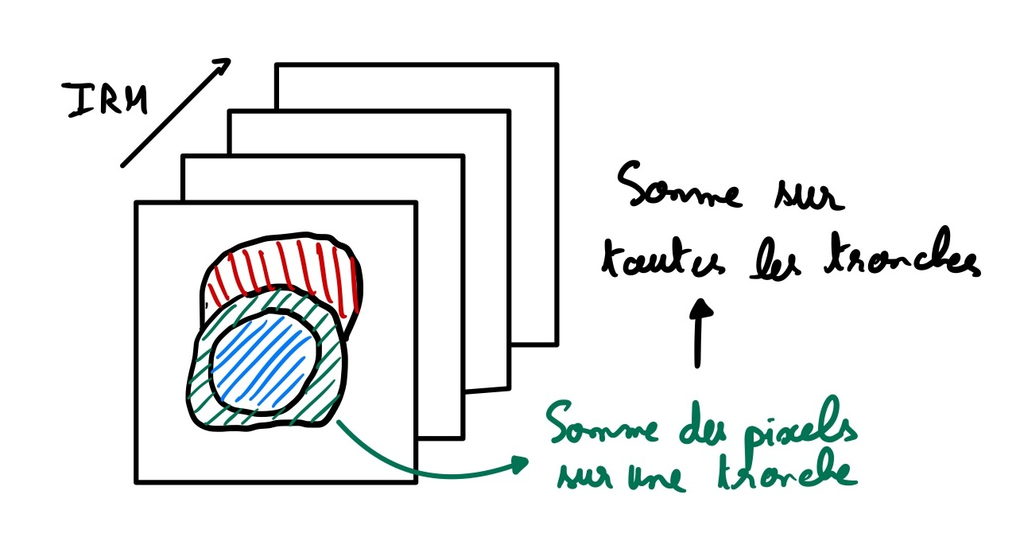

```python
from IPython.display import Image, display
display(Image(filename='volume.jpg', width=600))
```

```python
def volume(segmentation,label,space=1):
    """
    Fonction volume d'une segmentation 3D
    segmentation : tableau numpy de la segmentation
    label : label de la région d'intérêt
    space : taille des voxels en mm (par défaut 1)
    """
    # On crée un masque binaire pour la région d'intérêt
    masque = np.zeros_like(segmentation)
    masque[segmentation == label] = 1
    volume = np.sum(masque) * (space ** 3) # on multiplie par le volume d'un voxel
    return volume

# testons
volume_ED_RV, volume_ED_myocardium, volume_ED_LV = volume(load_ed_seg, 1, spacing_ed[0]), volume(load_ed_seg, 2, spacing_ed[0]), volume(load_ed_seg, 3, spacing_ed[0])
print(f"Volume du ventricule droit : {volume_ED_RV} mm3")
print(f"Volume du myocarde : {volume_ED_myocardium} mm3")
print(f"Volume du ventricule gauche : {volume_ED_LV} mm3")
```

```
Volume du ventricule droit : 36410.80890618134 mm3
Volume du myocarde : 15865.572205802897 mm3
Volume du ventricule gauche : 24850.528035387943 mm3
```

Par ailleurs il est tout de même très important de conserver cette valeure de spacing, puisque tous les patients n'ont pas le même nombre de slides. Cela nous permet donc de corriger cette différence et d'obtenir des proportions cohérentes entre les sujets.

### 3.2 Fraction d'éjection

La fraction d'éjection évalue la performance de la fonction cardiaque en mesurant à quel point le ventricule (gauche ou droit) pompe du sang au cours de la phase cardiaque. Il se calcule comme suit : $$ FE = \frac{\text{Volume}_{ED} - \text{Volume}_{ES}}{\text{Volume}_{ED}} $$ Une fraction d'éjection faible (<50%) est un signal d'alarme concernant l'une des pathologies. Pour la construction de nos features, on calculera cette mesure pour les ventricules droits et gauche. La myocarde ne se remplissant pas de sang, le calcul pour cette dernière ne fait pas grand sens physique.

Son implémentation est relativement directe :

```python
# on va calculer la fraction d'éjection avec : FEVG = (EDV – ESV) / EDV × 100
def frac_ejection(volume_ED, volume_ES):
    return (volume_ED - volume_ES) / volume_ED * 100

volume_ES_RV, volume_ES_myocardium, volume_ES_LV = volume(load_es_seg, 1, spacing_es[0]), volume(load_es_seg, 2, spacing_es[0]), volume(load_es_seg, 3, spacing_es[0])
FE_RV, FE_LV = frac_ejection(volume_ED_RV, volume_ES_RV), frac_ejection(volume_ED_LV, volume_ES_LV)
print(f"Fraction d'éjection du ventricule droit : {FE_RV} %\n Fraction d'éjection du ventricule gauche : {FE_LV} %")
```

```
Fraction d'éjection du ventricule droit : 25.655058043117744 %
 Fraction d'éjection du ventricule gauche : 46.39776454865751 %
```

### 3.3 Ratios et features pondérées

Un point que nous n'avons pour le moment pas pris en compte, est celui de la taille et du poids du patient. En effet, si nous choisissons de discriminer sur des features de volume, il parrait cohérent qu'un individu de 2 mètres et 100 Kg n'ait pas le même volume cardiaque qu'une personne d'1m50 et deux fois plus légère.

Pour cela le papier `Deep Learning Techniques for Automatic MRI [...]` mentionne l'utilisation d'un outil intéressant : le BSA (Body surface Area). Cette mesure peut se calculer rapidement avec la formule de *Du bois et Du Bois*: $$ BSA=0.007184 \cdot (poids^{0.425} \cdot taille^{0.725}) $$

En divisant les volumes LV et RV aux deux instants, et le volume de la myocarde par ce BSA, on optient des features "normalisées" qui devraient minimiser les différences physiques entre les sujets.

Pour implémenter cela on aura besoin des métadata. Implémentons donc tout de suite une fonction qui les charge dans un dictionnaire. Si on travaille sur le train, on chargera aussi la cible, tandis qu'on se contentera du poids et de la taille lorsque qu'on travaille sur le test.

```python
# Fonction pour charger les métadonnées d'un patient
def get_patient_metadata(patient_id, train=True):
    if train:
        metadata_path = "Dataset/metaDataTrain.csv"
    else:
        metadata_path = "Dataset/metaDataTest.csv"
    if not os.path.exists(metadata_path):
        print(f"ERREUR: Fichier de métadonnées {metadata_path} introuvable")
        return {}
    metadata_df = pd.read_csv(metadata_path)
    # print(metadata_df.head())
    patient_data = metadata_df[metadata_df['Id'] == patient_id]
    if train:
        return {
        'Height': patient_data['Height'].values[0],
        'Weight': patient_data['Weight'].values[0],
        'Category': patient_data['Category'].values[0]}
    else:
        return {
        'Height': patient_data['Height'].values[0],
        'Weight': patient_data['Weight'].values[0],}
```

Une autre feature qui nous est mentionnée dans le papier et qui nous semble cohérente est celle des ratios entre volumes des ventricules. Par exemple les ratios tels que **RV/LV volume** et **myocardium/LV volume** mettent en évidence un déséquilibre de volume entre les structures cardiaques d'intéret, ce qui est nottament le cas dans les pathologies RVA et HCM.

Leur calcul est immédiat:

```python
# ratio  RV/LV  aux deux instants
ratio_ED_RV_LV = volume_ED_RV / volume_ED_LV
ratio_ES_RV_LV = volume_ES_RV / volume_ES_LV

# ratio myocardium/LV aux deux instants
ratio_ED_myocardium_LV = volume_ED_myocardium / volume_ED_LV
ratio_ES_myocardium_LV = volume_ES_myocardium / volume_ES_LV

print(f"Ratio RV/LV à l'instant ED : {ratio_ED_RV_LV} \nRatio RV/LV à l'instant ES : {ratio_ES_RV_LV}")
print(f"Ratio myocardium/LV à l'instant ED : {ratio_ED_myocardium_LV} \nRatio myocardium/LV à l'instant ES : {ratio_ES_myocardium_LV}")
```

```
Ratio RV/LV à l'instant ED : 1.465192564694448
Ratio RV/LV à l'instant ES : 2.0321849501359925
Ratio myocardium/LV à l'instant ED : 0.6384400437370915
Ratio myocardium/LV à l'instant ES : 1.6178603807796916
```

### 3.4 Epaisseur de la myocarde

Pour conclure cette construction de l'ensemble des features que nous utiliserons, une dernière m'a semblée etre utile : l'épaisseur de la myocarde. En effet plusieurs papiers de recherche, en particulier ceux résumant les critères médicaux actuels (papier mentionné plus haut :`Deep Learning [...] for Automatic MRI [...] Diagnosis` mentionnent ce critère, et l'observation des pathologies 1,2 et 3 à l'oeuil nu révèle que les deux premières présentent souvent une myocarde fine, à l'inverse de la pathologie 3 et de sa myocarde épaisse.

Pour implémenter ce calcul on propose l'approche suivante.

- **Etape 1 :** Identifier le centre du ventricule gauche. On choisit en première approximation de considérer simplement la moyenne des coordonnées $(x,y)$ des pixels du LV. Cette approximation se révèle en réalité de bonne qualité et on la conservera donc pour la suite.
- **Etape 2 :** A partir de ce point central, on choisit une direction. Puis :
  - on projète une demi-droite dans cette direction
  - on détecte l'entrée dans la myocarde (si elle existe) et on la stocke
  - on détecte la sortie de la myocarde (si elle existe) et on la stocke Ces deux points d'entrée et de sortie, définissent un rayon.
- **Etape 3 :** On itère ce processus sur tous les angles autour de 360°, dans notre cas on fera le calcul de 36 rayons, tous les 10°.
- **Etape 4 :** De cet ensemble de rayons obtenus, on extrait le plus petit rayon, les plus grand, et la moyenne de ces rayons. On fera attention à ne pas prendre en compte les valeurs abérantes.

Ci dessous voici l'implémentation de cette méthode. Elle est composée de deux fonctions :

- `calculer_epaisseur_rayon` qui calcule un rayon pour une direction donnée. Elle retourne un entier correspondant à l'épaisseur de la myocarde à cet endroit (taille du rayon).
- `calculer_epaisseur_myocarde` qui itère ce processus pour tous les angles envisagés.

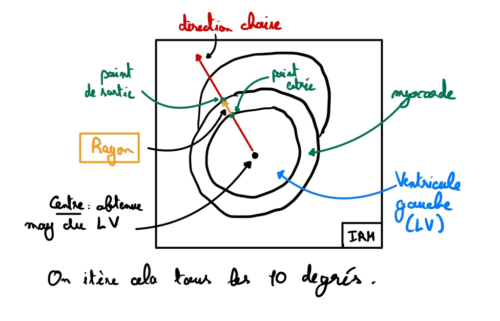

```python
from IPython.display import Image, display
display(Image(filename='rayons.jpg', width=800))
```

```python
def calculer_epaisseur_rayon(masque_myocarde, centre_x, centre_y, dx, dy):
    """Calcule l'épaisseur du myocarde le long d'un rayon donné"""
    h, w = masque_myocarde.shape
    max_length = np.sqrt(h**2 + w**2) # Longueur maximale du rayon
    points_interieur = []
    points_exterieur = []
    # Tracer le rayon
    for t in np.arange(0, max_length, 0.5):  # on avance avec un pas de 0.5 pixels
        x = int(centre_x+dx*t)
        y = int(centre_y+dy*t)
        if 0 <= x < w and 0 <= y < h:
            # Vérifier si on entre dans le myocarde
            if masque_myocarde[y, x] and not points_interieur:
                points_interieur.append((x, y, t))
            # Vérifier si on sort du myocarde après y être entré
            elif not masque_myocarde[y, x] and points_interieur and not points_exterieur:
                points_exterieur.append((x, y, t))
                break
    # Calculer l'épaisseur
    if points_interieur and points_exterieur:
        epaisseur = points_exterieur[0][2] - points_interieur[0][2]
        return epaisseur
    return 0
```

```python
def calculer_epaisseur_myocarde(segmentation, label_myocarde=2, label_vg=3, nb_angles=36):
    """Calcule l'épaisseur du myocarde en la fonction calculer_epaisseur_rayon définie ci-dessus"""
    epaisseurs_min = []
    epaisseurs_max = []
    epaisseurs_moy = []

    # Pour chaque tranche axiale contenant du myocarde
    for z in range(segmentation.shape[2]):
        tranche = segmentation[:,:,z]
        if np.any(tranche == label_myocarde) and np.any(tranche == label_vg):
            masque_myocarde = (tranche == label_myocarde)
            masque_vg = (tranche == label_vg)
            y_vg, x_vg = np.where(masque_vg)
            # Centre du ventricule gauche comme point de référence
            centre_x = np.mean(x_vg)
            centre_y = np.mean(y_vg)

            # Calculer l'épaisseur à différents angles (ici tous les 10 degrés)
            epaisseurs_tranche = []
            for i in range(nb_angles):
                angle = 2 * np.pi * i / nb_angles
                dx = np.cos(angle)
                dy = np.sin(angle)
                # Appel à notre fonction de calcul d'épaisseur
                epaisseur = calculer_epaisseur_rayon(masque_myocarde, centre_x, centre_y, dx, dy)
                if epaisseur > 0:  # Ignorer les rayons qui ne traversent pas le myocarde
                    epaisseurs_tranche.append(epaisseur)
            # Calculer statistiques pour cette tranche
            if epaisseurs_tranche:
                epaisseurs_min.append(np.min(epaisseurs_tranche))
                epaisseurs_max.append(np.max(epaisseurs_tranche))
                epaisseurs_moy.append(np.mean(epaisseurs_tranche))
    # Calculer les statistiques globales
    if epaisseurs_moy:
        epaisseur_max = np.percentile(epaisseurs_max, 95) # il est possible d'avoir des valeurs aberrantes
        epaisseur_min = np.percentile(epaisseurs_min, 5) # on les enlève à l'aide de percentiles
        epaisseur_moy = np.mean(epaisseurs_moy) # pour les valeurs moyennes, on suppose qu'elles sont négligeables
        return {
            'min': epaisseur_min,
            'max': epaisseur_max,
            'moy': epaisseur_moy
        }
    else:
        return {
            'min': 0,
            'max': 0,
            'moy': 0
        }
```

Enfin il nous faut une fonction pour visualiser ces épaisseurs calculées. La fonction ci dessous s'en charge.

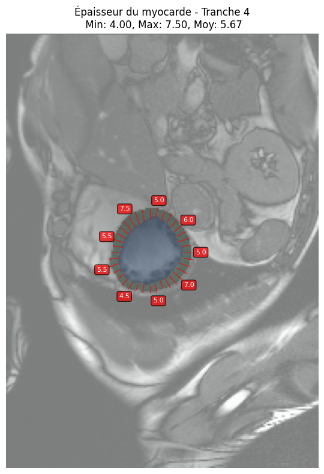

```python
def visualiser_epaisseur_myocarde(segmentation, img_data, tranche=None, label_myocarde=2, label_vg=3, nb_angles=36):
    """Visualise l'épaisseur du myocarde sur une tranche donnée"""
    # Sélection d'une tranche appropriée si non spécifiée
    if tranche is None:
        surfaces = []
        for z in range(segmentation.shape[2]):
            surfaces.append(np.sum(segmentation[:,:,z] == label_myocarde))
        tranche = np.argmax(surfaces)

    # Récupérer la tranche
    slice_seg = segmentation[:,:,tranche]
    slice_img = img_data[:,:,tranche]

    # Extraire les masques
    masque_myocarde = (slice_seg == label_myocarde)
    masque_vg = (slice_seg == label_vg)

    # Trouver le centre du ventricule gauche
    y_vg, x_vg = np.where(masque_vg)
    centre_x, centre_y = np.mean(x_vg), np.mean(y_vg)

    # Créer une image pour visualisation
    fig, ax = plt.subplots(figsize=(10, 8))
    ax.imshow(slice_img, cmap='gray')
    ax.imshow(masque_myocarde, alpha=0.3, cmap='Greens')
    ax.imshow(masque_vg, alpha=0.3, cmap='Blues')

    # Tracer les rayons et mesures d'épaisseur
    epaisseurs = []
    for i in range(nb_angles):
        angle = 2 * np.pi * i / nb_angles
        dx = np.cos(angle)
        dy = np.sin(angle)
        # Calculer l'épaisseur le long de ce rayon
        epaisseur = calculer_epaisseur_rayon(masque_myocarde, centre_x, centre_y, dx, dy)
        if epaisseur > 0:
            epaisseurs.append(epaisseur)
            # Dessiner le rayon
            # Point de départ: bordure intérieure du myocarde
            t_start = 0
            while True:
                x = int(centre_x + dx * t_start)
                y = int(centre_y + dy * t_start)
                if masque_myocarde[y, x]:
                    break
                t_start += 0.5
            # Point d'arrivée: épaisseur le long du rayon
            t_end = t_start + epaisseur
            # Dessiner la ligne
            x_start = centre_x + dx * t_start
            y_start = centre_y + dy * t_start
            x_end = centre_x + dx * t_end
            y_end = centre_y + dy * t_end

            ax.plot([x_start, x_end], [y_start, y_end], 'r-', linewidth=0.7)
            if i % 4 == 0:  # Afficher un texte tous les 4 rayons pour éviter l'encombrement
                ax.text(x_end + dx*5, y_end + dy*5, f"{epaisseur:.1f}", color='white',
                        fontsize=8, ha='center', va='center',
                        bbox=dict(boxstyle="round", fc="red", alpha=0.7))

    ax.set_title(f"Épaisseur du myocarde - Tranche {tranche}\n Min: {np.min(epaisseurs):.2f}, Max: {np.max(epaisseurs):.2f}, Moy: {np.mean(epaisseurs):.2f}")
    ax.axis('off')
    plt.tight_layout()
    plt.show()
    return epaisseurs

epaisseur = visualiser_epaisseur_myocarde(load_ed_seg, load_ed, tranche=load_ed.shape[2]//2)
```

```python
rayons = calculer_epaisseur_myocarde(load_ed_seg)
print(f"Rayons :\n min : {rayons['min']},\n max : {rayons['max']},\n moy : {rayons['moy']}")
```

```
Rayons :
 min : 2.175,
 max : 8.325,
 moy : 5.135416666666666
```

### 3.5 Construction finale des features

Pour automatiser l'extraction des features pour chaque patient, on utilise l'ensemble des fonctions implémentées plus haut, qu'on appelle successivement pour constituer un dataframe.

Après extraction de ces features, on obtient un dataset de **24 features** que l'on peut résumer ci dessous:

| Type de feature | Exemples |
| --- | --- |
| Volumes (8) | LV ED/ES volume, RV ED/ES volume, Myocarde volume et masse |
| Fractions Ejection (2) | LV EF, RV EF |
| Ratios/Pondérées (6) | LV/RV/Myocarde volumes par rapport BSA, RV/LV and Myo/LV ratios |
| Rayons (3) | Epaisseur Myocarde (min/max/mean) |
| Physiques (3) | Taille, Poids, BSA |

On stocke cela dans un fichier CSV, de manière à pouvoir le rapeller facilement dans toute la suite du projet. Ceci conclut toute la phase de "pré-processing".

```python
# Fonction pour extraire toutes les features d'un patient
def extract_features(patient_id, train=True, bsa = False, rayons=False, verbose=False):
    id_af = patient_id
    if isinstance(patient_id, int):
        if patient_id < 10:
            patient_id = f"00{patient_id}"
        elif patient_id < 100:
            patient_id = f"0{patient_id}"
        else:
            patient_id = str(patient_id)
    if train:
        patient_dir = f"Dataset/Train/{patient_id}"
    else:
        patient_dir = f"Dataset/Test/{patient_id}"

    ed_path = os.path.join(patient_dir, f"{patient_id}_ED.nii")
    es_path = os.path.join(patient_dir, f"{patient_id}_ES.nii")
    ed_seg_path = os.path.join(patient_dir, f"{patient_id}_ED_seg.nii")
    es_seg_path = os.path.join(patient_dir, f"{patient_id}_ES_seg.nii")

    for path in [ed_path, es_path, ed_seg_path, es_seg_path]:
        if not os.path.exists(path):
            print(f"ERREUR: Fichier {path} introuvable pour patient {patient_id}")
            return None

    try:
        seg_ed,_, spacing_ed_seg = load_seg(ed_seg_path)
        seg_es,_, spacing_es_seg = load_seg(es_seg_path)

        # Remplissage du ventricule gauche si test
        if not train:
            seg_ed = fill_LV_test_2D(seg_ed)
            seg_es = fill_LV_test_2D(seg_es)

        # Calcul des volumes
        volume_ED_RV = volume(seg_ed, 1, spacing_ed_seg[0]) / 1000  # mm^3 => mL
        volume_ED_myocardium = volume(seg_ed, 2, spacing_ed_seg[0]) / 1000
        volume_ED_LV = volume(seg_ed, 3, spacing_ed_seg[0]) / 1000

        volume_ES_RV = volume(seg_es, 1, spacing_es_seg[0]) / 1000
        volume_ES_myocardium = volume(seg_es, 2, spacing_es_seg[0]) / 1000
        volume_ES_LV = volume(seg_es, 3, spacing_es_seg[0]) / 1000

        # Calcul des fractions d'éjection
        FE_RV = frac_ejection(volume_ED_RV, volume_ES_RV)
        FE_LV = frac_ejection(volume_ED_LV, volume_ES_LV)

        # Calcul des ratios
        ratio_ED_RV_LV = volume_ED_RV / volume_ED_LV if volume_ED_LV > 0 else 0
        ratio_ES_RV_LV = volume_ES_RV / volume_ES_LV if volume_ES_LV > 0 else 0
        ratio_ED_myocardium_LV = volume_ED_myocardium / volume_ED_LV if volume_ED_LV > 0 else 0
        ratio_ES_myocardium_LV = volume_ES_myocardium / volume_ES_LV if volume_ES_LV > 0 else 0

        # Calcul de la masse du myocarde (densité myocarde = 1.05 g/mL)
        myocardium_mass = volume_ED_myocardium * 1.05

        # Recherche des métadonnées du patient
        metadata = get_patient_metadata(id_af,train)
        height = metadata.get('Height',None)
        weight = metadata.get('Weight',None)
        if train:
            category = metadata.get('Category',None)

        # Construction du dictionnaire de features
        features = {
            'patient_id': patient_id,
            'volume_LV_ED': volume_ED_LV,
            'volume_LV_ES': volume_ES_LV,
            'volume_RV_ED': volume_ED_RV,
            'volume_RV_ES': volume_ES_RV,
            'volume_myocardium_ED': volume_ED_myocardium,
            'volume_myocardium_ES': volume_ES_myocardium,
            'FE_LV': FE_LV,
            'FE_RV': FE_RV,
            'myocardium_mass': myocardium_mass,
            'ratio_ED_RV_LV': ratio_ED_RV_LV,
            'ratio_ES_RV_LV': ratio_ES_RV_LV,
            'ratio_ED_myocardium_LV': ratio_ED_myocardium_LV,
            'ratio_ES_myocardium_LV': ratio_ES_myocardium_LV,
            'height': height,
            'weight': weight,
        }

        if bsa:
            # BSA (Body Surface Area) - Formule de Mosteller
            if height and weight:
                bsa = 0.007184*(weight**(0.425)*height**(0.725))
                features['bsa'] = bsa

                # Indexation des volumes par BSA
                features['volume_LV_ED_indexed'] = volume_ED_LV / bsa
                features['volume_LV_ES_indexed'] = volume_ES_LV / bsa
                features['volume_RV_ED_indexed'] = volume_ED_RV / bsa
                features['volume_RV_ES_indexed'] = volume_ES_RV / bsa
                features['myocardium_mass_indexed'] = myocardium_mass / bsa

        if rayons:
            rayons_moycarde = calculer_epaisseur_myocarde(seg_ed, label_myocarde=2, label_vg=3)
            features['rayon_min'] = rayons_moycarde['min']
            features['rayon_max'] = rayons_moycarde['max']
            features['rayon_moy'] = rayons_moycarde['moy']

        if train:
            features['category'] = category
        return features

    except Exception as e:
        print(f"Erreur lors du traitement du patient {patient_id}: {e}")
        return None
```

```python
# Fonction pour traiter tous les patients et créer un CSV
def create_features_csv(train=True, bsa=False, rayons=False):
    if train:
        train_dir = "Dataset/Train"
        output_path = "cardiac_features_train.csv"
    else:
        train_dir = "Dataset/Test"
        output_path = "cardiac_features_test.csv"
    all_features = []
    if train:
        tqdm_range = tqdm(range(1, 101), desc="Traitement des patients")
    else:
        tqdm_range = tqdm(range(101, 151), desc="Traitement des patients")
    for patient_id in tqdm_range:
        features = extract_features(patient_id, train=train, bsa=bsa, rayons=rayons)
        if features:
            all_features.append(features)
    features_df = pd.DataFrame(all_features)

    features_df.to_csv(output_path, index=False)
    print(f"Features sauvegardées dans {output_path}")
    print(f"Total: {len(features_df)} patients traités")
    return features_df

features_df = create_features_csv(train=True, bsa=True, rayons=True)
features_df_test = create_features_csv(train=False, bsa=True, rayons=True)
display(features_df.head())
display(features_df.describe())
```

```
Features sauvegardées dans cardiac_features_train.csv
Total: 100 patients traités
```

```
Features sauvegardées dans cardiac_features_test.csv
Total: 50 patients traités
```

|  | patient_id | volume_LV_ED | volume_LV_ES | volume_RV_ED | volume_RV_ES | volume_myocardium_ED | volume_myocardium_ES | FE_LV | FE_RV | myocardium_mass | ... | bsa | volume_LV_ED_indexed | volume_LV_ES_indexed | volume_RV_ED_indexed | volume_RV_ES_indexed | myocardium_mass_indexed | rayon_min | rayon_max | rayon_moy | category |
| --- | --- | --- | --- | --- | --- | --- | --- | --- | --- | --- | --- | --- | --- | --- | --- | --- | --- | --- | --- | --- | --- |
| 0 | 001 | 46.173096 | 35.251617 | 21.831512 | 9.304047 | 25.665283 | 30.479431 | 23.653338 | 57.382492 | 26.948547 | ... | 2.182186 | 21.159101 | 16.154268 | 10.004423 | 4.263636 | 12.349335 | 2.400 | 8.300 | 5.103395 | 2 |
| 1 | 002 | 36.332242 | 25.744602 | 12.910634 | 3.940657 | 21.934278 | 26.327267 | 29.141169 | 69.477435 | 23.030992 | ... | 1.731889 | 20.978393 | 14.865044 | 7.454656 | 2.275352 | 13.298194 | 1.725 | 9.500 | 5.656944 | 2 |
| 2 | 003 | 43.235779 | 37.670135 | 30.052185 | 27.278900 | 29.975891 | 31.417847 | 12.872772 | 9.228231 | 31.474686 | ... | 1.844169 | 23.444585 | 20.426617 | 16.295786 | 14.791973 | 17.067136 | 1.175 | 9.000 | 5.841667 | 2 |
| 3 | 004 | 35.662688 | 30.963033 | 14.528297 | 11.558749 | 23.030609 | 23.919940 | 13.178072 | 20.439754 | 24.182139 | ... | 1.442286 | 24.726506 | 21.468030 | 10.073106 | 8.014188 | 16.766538 | 1.900 | 9.275 | 5.955556 | 2 |
| 4 | 005 | 40.893345 | 31.513321 | 23.971481 | 10.484047 | 28.320831 | 32.661839 | 22.937776 | 56.264501 | 29.736873 | ... | 1.844169 | 22.174401 | 17.088086 | 12.998527 | 5.684970 | 16.124808 | 2.225 | 9.775 | 6.541667 | 2 |

5 rows × 26 columns

|  | volume_LV_ED | volume_LV_ES | volume_RV_ED | volume_RV_ES | volume_myocardium_ED | volume_myocardium_ES | FE_LV | FE_RV | myocardium_mass | ratio_ED_RV_LV | ... | bsa | volume_LV_ED_indexed | volume_LV_ES_indexed | volume_RV_ED_indexed | volume_RV_ES_indexed | myocardium_mass_indexed | rayon_min | rayon_max | rayon_moy | category |
| --- | --- | --- | --- | --- | --- | --- | --- | --- | --- | --- | --- | --- | --- | --- | --- | --- | --- | --- | --- | --- | --- |
| count | 100.000000 | 100.000000 | 100.000000 | 100.000000 | 100.000000 | 100.000000 | 100.000000 | 100.000000 | 100.000000 | 100.000000 | ... | 100.000000 | 100.000000 | 100.000000 | 100.000000 | 100.000000 | 100.000000 | 100.000000 | 100.000000 | 100.000000 | 100.000000 |
| mean | 27.450019 | 16.193917 | 27.147883 | 15.436889 | 20.300085 | 23.058345 | 46.384599 | 46.732087 | 21.315089 | 1.086752 | ... | 1.861977 | 14.723605 | 8.705712 | 14.613374 | 8.337796 | 11.386783 | 1.797750 | 9.786000 | 5.450627 | 2.000000 |
| std | 13.020152 | 12.300326 | 16.204484 | 12.346750 | 8.064111 | 9.161467 | 19.921476 | 17.887314 | 8.467316 | 0.601677 | ... | 0.229922 | 6.785673 | 6.581088 | 8.583509 | 6.555342 | 4.179071 | 0.812692 | 3.725501 | 1.734058 | 1.421338 |
| min | 7.698059 | 2.798756 | 6.475762 | 1.491462 | 8.051414 | 9.246826 | 10.476731 | 1.916872 | 8.453985 | 0.312121 | ... | 1.170949 | 4.229355 | 1.890885 | 3.520757 | 0.964248 | 3.964276 | 0.500000 | 5.000000 | 3.032986 | 0.000000 |
| 25% | 18.492081 | 6.907631 | 15.757017 | 7.440720 | 14.727011 | 16.325367 | 27.975639 | 38.163055 | 15.463361 | 0.732278 | ... | 1.711941 | 9.854052 | 3.451315 | 9.403005 | 3.882480 | 8.148363 | 1.193750 | 7.750000 | 4.423611 | 1.000000 |
| 50% | 23.324612 | 10.639596 | 23.567382 | 10.984396 | 18.867889 | 22.612839 | 53.651994 | 48.408060 | 19.811283 | 0.962378 | ... | 1.844169 | 12.247742 | 5.958532 | 11.601343 | 5.910324 | 10.537042 | 1.725000 | 8.800000 | 5.130208 | 2.000000 |
| 75% | 36.280642 | 24.814038 | 31.004807 | 19.364485 | 25.730456 | 28.488038 | 62.239109 | 60.036018 | 27.016978 | 1.238155 | ... | 2.024147 | 19.894996 | 12.624078 | 17.293333 | 11.599218 | 14.440320 | 2.206250 | 10.500000 | 5.940972 | 3.000000 |
| max | 58.323160 | 51.989502 | 95.608127 | 73.258113 | 41.281311 | 51.716791 | 81.867936 | 85.941946 | 43.345377 | 3.609019 | ... | 2.454556 | 32.964948 | 29.449938 | 47.795370 | 36.622395 | 20.662262 | 5.000000 | 25.950000 | 13.595486 | 4.000000 |

8 rows × 25 columns

## 4. Baseline

### 4.1 Analyse de la data (EDA)

Une étape intéressante avant de se lance tête baissée dans l'entrainement d'un modèle est de chercher à visualiser la data qu'on vient de construire, les liens entre les features, et identifier en amont les challenges potentiels à venir.

Premier point : le dataset est équilibré. Cela implique qu'un ré equilibrage des classes ne sera pas nécessaire, et que la mesure de performance fournie sera suffisante. Cette dernière est l'**Accuracy**, définie par : $$ \text{Acc} = \frac{1}{N} \sum_{i=1}^{N} I(y_i = f_i) $$ où:

- $N$: le nombre de sujets,
- $y_i$ le label correct (ground truth) pour le sujet $i$,
- $f_i$ est notre prédiction

Désormais, explorons les distributions de features qu'on a identifiées comme clés plus haut dans ce rapport. On propose ainsi de calculer des boxplots sur les 2 fractions d'ejection, par rapport aux 5 classes à classifier. Le code ci dessous s'en charge.

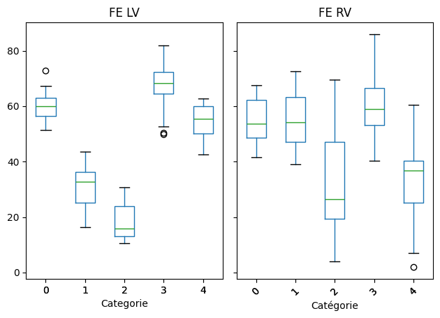

```python
# fonction qui va nous permettre de faire des boxplots sur les fractions d'éjection et les ratios
def boxplot_FE(metadata, fe_lv, fe_rv):
    data = {'FE LV': fe_lv,'FE RV': fe_rv,'Categorie': metadata['category']
    }
    df = pd.DataFrame(data)
    plt.figure(figsize=(14,4))
    df.boxplot(column=['FE LV', 'FE RV'], by='Categorie', grid=False)
    plt.suptitle('')
    plt.ylabel('Fraction d\'Éjection (%)')
    plt.xlabel('Catégorie')
    plt.xticks(rotation=45)
    plt.tight_layout()
    plt.show()
boxplot_FE(features_df, features_df['FE_LV'], features_df['FE_RV'])
```

Une autre opération plutot rapide et qui peut réveler de bonnes informations est le calcul d'une matrice de corrélation entre les features.

En visualisant cela, on remarque tout de suite que les features sur le volume et celles sur les volumes pondérés ainsi que la masse de la myocarde sont très corrélées. En effet, ce sont quasiment les même à un rapport près.

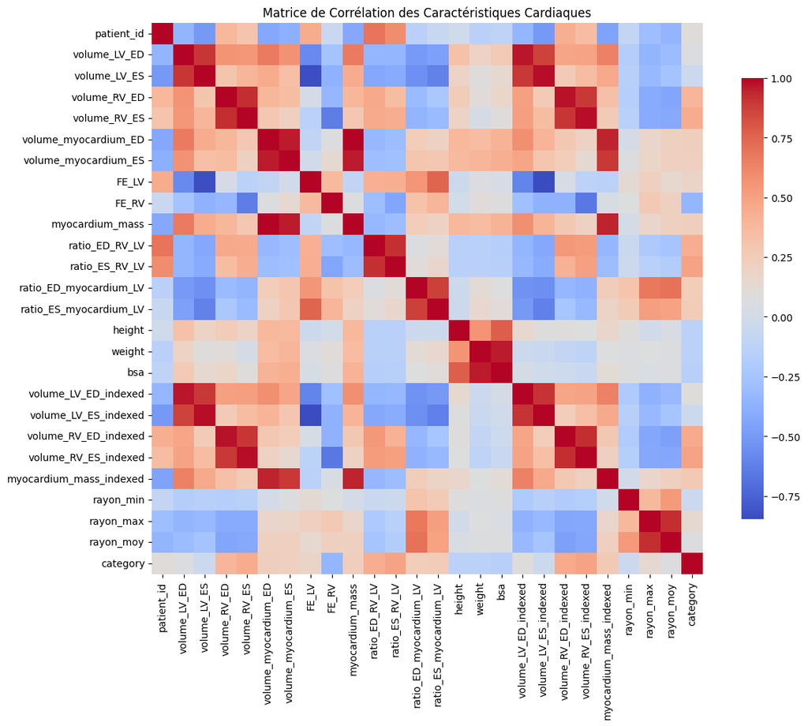

```python
def plot_correlation_matrix(df):
    corr = df.corr()
    plt.figure(figsize=(14, 10))
    sns.heatmap(corr, annot=False, fmt=".2f", cmap='coolwarm', square=True, cbar_kws={"shrink": .8})
    plt.title('Matrice de Corrélation des Caractéristiques Cardiaques')
    plt.show()
import seaborn as sns
plot_correlation_matrix(features_df)
```

### 4.2 Baseline Naïve

Une idée interessante qui m'est alors venu en tête est celle d'utiliser les critères médicaux dont on a parlé plus haut pour voir si on arrive déja à classifier un petit peu les patient. Pour cela on reprend les critères basiques sur les volumes et les fractions d'éjections, et on implémente classifieur naif.

```python
def prediction_naive(features_df):
    mean_volume_LV_ED = features_df['volume_LV_ED'].mean()
    mean_volume_LV_ES = features_df['volume_LV_ES'].mean()
    mean_FE_LV = features_df['FE_LV'].mean()
    mean_FE_RV = features_df['FE_RV'].mean()
    predicted_categories = []

    for index, row in features_df.iterrows():
        volume_LV_ED = row['volume_LV_ED']
        volume_LV_ES = row['volume_LV_ES']
        FE_LV = row['FE_LV']
        FE_RV = row['FE_RV']

        # Critères pour chaque catégorie
        if (FE_LV > 50) and (volume_LV_ED < mean_volume_LV_ED) and (volume_LV_ES < mean_volume_LV_ES) and (FE_RV > 40):
            predicted_categories.append('0')
        elif (FE_LV < 40) and (volume_LV_ED > mean_volume_LV_ED):
            predicted_categories.append('2')
        elif (FE_LV < 40) and (volume_LV_ED > mean_volume_LV_ED) and (row['rayon_moy'] < 10):
            predicted_categories.append('1')
        elif (FE_LV > 55) and (row['rayon_moy'] > 10):
            predicted_categories.append('3')
        elif (volume_LV_ED > mean_volume_LV_ED) and (FE_RV < 40):
            predicted_categories.append('4')
        else:
            predicted_categories.append('UNKNOWN')
    return predicted_categories
```

- Si on réalise une prédiction au hasard complet, on devrait etre à 20% d'accuracy. Ce n'est donc pas bien mieux que le hasard à priori.
- Les classes 1 et 2 sont encore une fois superposées.

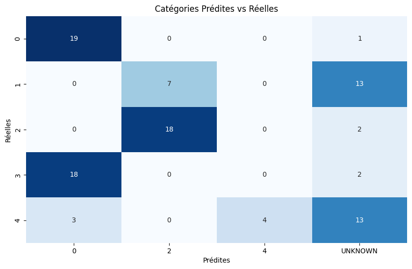

```
Accuracy de la prédiction naïve : 28.00%
```

```python
features_df_naif = features_df.copy()
features_df_naif['predicted_category'] = prediction_naive(features_df_naif)
contingency_table = pd.crosstab(features_df_naif['category'], features_df_naif['predicted_category'], rownames=['Réelles'], colnames=['Prédites'])
def plot_contingency_table(contingency_table):
    plt.figure(figsize=(10, 6))
    sns.heatmap(contingency_table, annot=True, fmt='d', cmap='Blues', cbar=False)
    plt.title('Catégories Prédites vs Réelles')
    plt.xlabel('Prédites')
    plt.ylabel('Réelles')
    plt.show()
plot_contingency_table(contingency_table)

# accuracy de la prédiction naïve
def calculate_accuracy(contingency_table):
    correct_predictions = np.trace(contingency_table.values)
    total_predictions = np.sum(contingency_table.values)
    accuracy = correct_predictions / total_predictions
    return accuracy
print(f"Accuracy de la prédiction naïve : {calculate_accuracy(contingency_table):.2%}")
```

Pour établir un point de départ un peu plus solide, essayons une baseline avec un "vrai" modèle cette fois ci.

## 5. Random Forest

### 5.1 Modèle simple

On commence par implémenter un **Random Forest (RF)** avec des paramètres de défault et 100 arbres.

Choisir un tel modèle au départ nous permettra d'observer simplement les features les plus importantes, grâce à la grande "explainibility" des arbres.

On choisit d'implémenter immédiatement avec une cross validation sur 5 folds. Ce petit ajout de code nous permettra d'améliorer grandement la fiabilité de nos résultat.

Dans toute la suite du projet, sauf mention contraire, tout entrainement de modèle sera fait en cross validation sur 5 folds.

```
Accuracy moyenne sur 5 folds: 0.89 ± 0.07
```

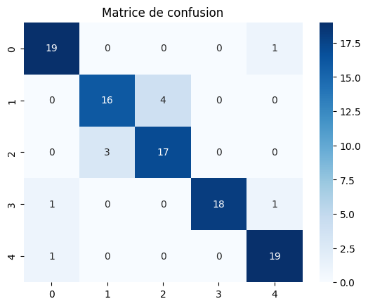

```python
from sklearn.ensemble import RandomForestClassifier
from sklearn.model_selection import StratifiedKFold
from sklearn.metrics import confusion_matrix, classification_report
from sklearn.preprocessing import StandardScaler
from sklearn.metrics import accuracy_score

target_col = 'category'
random_state = 12

kf = StratifiedKFold(n_splits=5, shuffle=True, random_state=random_state)
X = features_df.drop(columns=[target_col, 'patient_id'])
y = features_df[target_col]
results = []
y_test_global = []
y_pred_global = []

for train_index, test_index in kf.split(X, y):
    X_train, X_test = X.iloc[train_index], X.iloc[test_index]
    y_train, y_test = y.iloc[train_index], y.iloc[test_index]
    # Normaliser les données
    scaler = StandardScaler()
    X_train_scaled = scaler.fit_transform(X_train)
    X_test_scaled = scaler.transform(X_test)
    # Entraîner le modèle
    rf_model = RandomForestClassifier(random_state=random_state, n_jobs=-1, n_estimators=100)
    rf_model.fit(X_train_scaled, y_train)
    # Prédire et évaluer
    y_pred = rf_model.predict(X_test_scaled)
    accuracy = accuracy_score(y_test, y_pred)
    results.append(accuracy)

    y_test_global.extend(y_test)
    y_pred_global.extend(y_pred)

# Afficher les résultats
print(f"Accuracy moyenne sur {len(results)} folds: {np.mean(results):.2f} ± {np.std(results):.2f}")
cm = confusion_matrix(y_test_global, y_pred_global)
sns.heatmap(cm, annot=True, fmt='d', cmap='Blues', xticklabels=np.unique(y), yticklabels=np.unique(y))
plt.title("Matrice de confusion")
plt.show()
```

L'accuracy obtenue est de $89\% \pm 0.07$.

La matrice de confusion nous montre néanmoins ce qu'on redoutait : les classes 1 et 2 semblent difficiles à distinguer.

### 5.2 Importance des features

L'un des grands avantage des Random Forest est leur interprétabilité. On peut ainsi afficher un graphique des features par ordre d'importance. Ce calcul est fait grâce à un score de pureté aussi appellée **Gini importance**.

Cette dernière est calculée lors de l'entrainement du Random Forest. En effet pour chaque arbre on détermine le split qui reduit le plus l'impureté. Cette impureté de Gini pour un noeud $C$ est définie comme suit :

$$ \text{Gini} = 1 - \sum_{i=1}^{C} p_i^2 $$

où $p_i$ est la proportion d'échantillons de la classe $i$ dans le noeud.

L'importance des features est alors calculée comme étant :

- Par arbre, la somme des réduction d'impureté que cette feature apporte
- On moyenne sur tous les arbres.

Implémentons ceci, et visualisons le résultat ci dessous

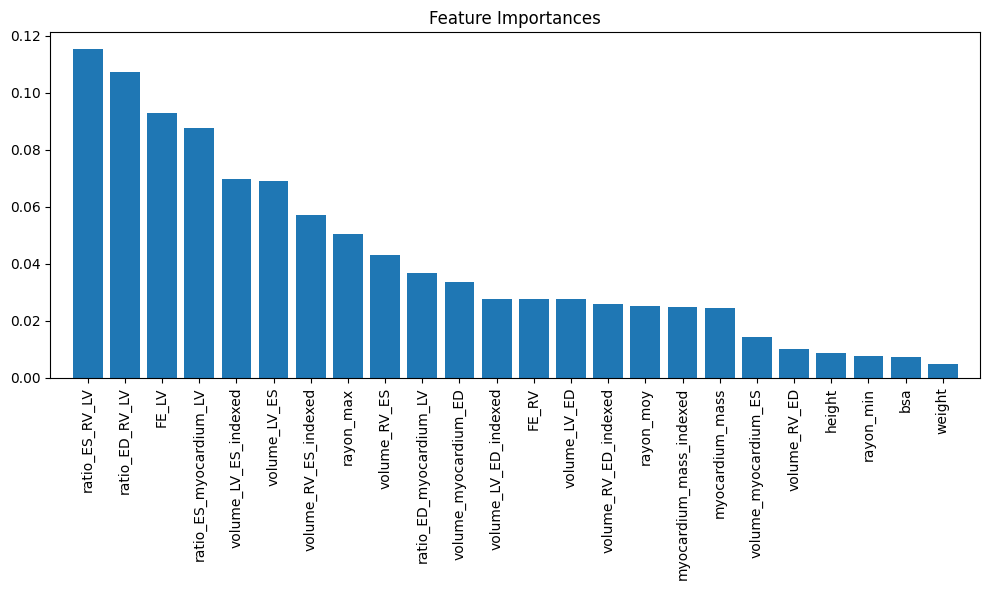

```python
importances = rf_model.feature_importances_
feature_names = X.columns
indices = np.argsort(importances)[::-1]
plt.figure(figsize=(10, 6))
plt.title("Feature Importances")
plt.bar(range(X.shape[1]), importances[indices], align="center")
plt.xticks(range(X.shape[1]), feature_names[indices], rotation=90)
plt.xlim([-1, X.shape[1]])
plt.tight_layout()
plt.show()
```

On voit remarques immédiatement quelques résultats remarquables :

- **Les ratios et les fractions d'ejections** sont parmis les features les plus importantes.
- Les features **compensées** par BSA sont systématiquement légèrement au dessus de la même feature sans conpensation.
- Enfin, le **rayon max** est dans le top des features, ce qui nous rassure sur son utilité.

En voyant ce graphique des features m'est alors venu une idée. Puisque depuis le début le problème principal qui semblent s'imposer est celui d'un overfitting du fait du faible nombre de données, ne pourrait on pas amincir ce dataset sur lequel nous travaillons ?

On propose une solution dans la partie suivante. Avant cela, réalisont une prédiction sur le test set pour la soumission Kaggle.

```python
df_train = pd.read_csv("cardiac_features_train.csv")
df_test = pd.read_csv("cardiac_features_test.csv")

scaler = StandardScaler()
X_train = df_train.drop(columns=[target_col, 'patient_id'])
y_train = df_train[target_col]
X_test = df_test.drop(columns=['patient_id'])
# Normalisation des données
X_train_scaled = scaler.fit_transform(X_train)
X_test_scaled = scaler.transform(X_test)

# Entraînement du modèle sur l'ensemble des données
rf_model = RandomForestClassifier(random_state=random_state, n_jobs=-1, n_estimators=100)
rf_model.fit(X_train_scaled, y_train)
# Prédire sur le jeu de test
y_pred = rf_model.predict(X_test_scaled)
# Sauvegarder les résultats dans un fichier CSV
def save_test_predictions_to_csv(predictions, output_path="predictions_3105_100.csv"):
    df_test = pd.read_csv("cardiac_features_test.csv")
    df_test['prediction'] = predictions
    # il faut renomer la colonne patient_id en Id et prediction en Category
    df_test.rename(columns={'patient_id': 'Id', 'prediction': 'Category'}, inplace=True)
    df_test = df_test[['Id', 'Category']]
    df_test.to_csv(output_path, index=False)
    print(f"Prédictions sauvegardées dans {output_path}")
save_test_predictions_to_csv(y_pred, output_path="predictions_3105_100.csv")
```

```
Prédictions sauvegardées dans predictions_3105_100.csv
```

Une fois notre prédiction réalisée, si on l'observe un peu plus on remarque qu'elle n'est pas équilibrée.

Or on s'attend à une prédiction équilibrée, ce qui nous indique immédiatement qu'on aura pas 100%. C'est une information utile, car si par la suite on obtient une prédiction à 1 d'accuracy sur le leaderboard public, mais qu'elle n'est pas équilibré, on sait tout de suite qu'elle ne sera pas représentative de nos performances réelles.

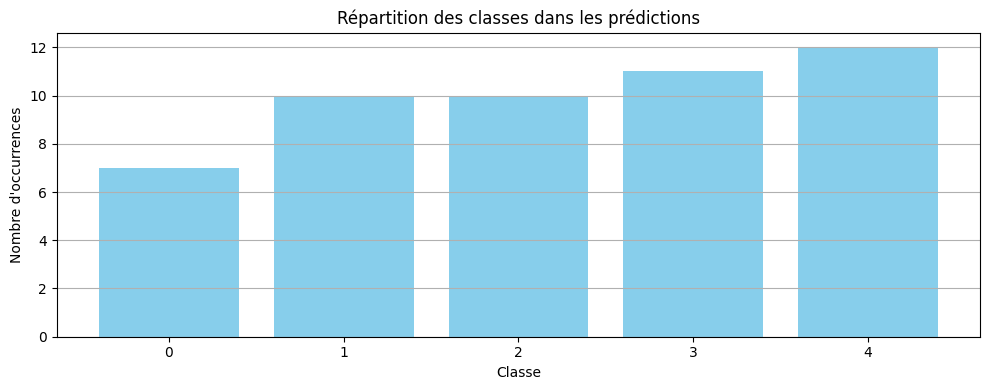

```python
# Compter le nombre d'occurrences de chaque classe
class_counts = pd.Series(y_pred).value_counts().sort_index()
class_counts_df = pd.DataFrame({'Classe': class_counts.index, 'Nombre': class_counts.values})
plt.figure(figsize=(10,4))
plt.bar(class_counts_df['Classe'], class_counts_df['Nombre'], color='skyblue')
plt.title("Répartition des classes dans les prédictions")
plt.xlabel("Classe")
plt.ylabel("Nombre d'occurrences")
plt.xticks(class_counts_df['Classe'])
plt.grid(axis='y')
plt.tight_layout()
plt.show()
```

### 5.3 Feature Selection

Comme mentionné plus haut, si nous voulons réduire l'overfitting il parait cohérent de diminuer le nombre de features que nous utilisons.

Pour cela, on propose la stratégie suivante :

- **Initialisation :** On entraine un Random Forest sur l'ensemble des 24 features dont on dispose.
- **Boucle :** On réalise alors de manière successive :
  - Une classification des features par ordre d'importance, et on supprime la moins importante.
  - On ré-entraine avec cet ensemble réduit de features On obtient au final 24 entrainements, dont on sélectionnera celui avec les meilleurs performances en cross validation.

Implémentons cela.

```python
from sklearn.model_selection import cross_val_score

X_full = df_train.drop(columns=[target_col, 'patient_id'])
y_full = df_train[target_col]


current_features = X_full.columns.tolist()
# les resultats seront renvoyés sous forme d'un dictionnaire, avec le nombre de features, leur liste, et l'accuracy
results = []

while len(current_features) > 1:
    X_subset = X_full[current_features] # on ne train que sur les features restantes
    model = RandomForestClassifier(random_state=42, n_estimators=100)
    cv_scores = cross_val_score(model, X_subset, y_full, cv=5, scoring="accuracy")
    mean_score = cv_scores.mean()

    model.fit(X_subset, y_full)

    # on regarde la feature la moins importante
    importances = model.feature_importances_
    idx_min = np.argmin(importances)
    removed_feature = current_features[idx_min]
    print(f"La feature la moins importante est {removed_feature} avec une importance de {importances[idx_min]:.4f}")
    print(f"Accuracy avec {len(current_features)} features : {mean_score:.4f}")
    current_features.pop(idx_min)

    results.append({
        "n_features": len(current_features)+1,
        "feature_removed": removed_feature,
        "mean_accuracy": mean_score
    })

# Si une seule feature reste, on évalue aussi
if len(current_features) == 1:
    X_subset = X_full[current_features]
    model = RandomForestClassifier(random_state=42, n_estimators=100)
    cv_scores = cross_val_score(model, X_subset, y_full, cv=5, scoring="accuracy")
    mean_score = cv_scores.mean()
    results.append({
        "n_features": len(current_features),
        "feature_removed": current_features.copy(),
        "mean_accuracy": mean_score
    })
```

```
La feature la moins importante est weight avec une importance de 0.0049
Accuracy avec 24 features : 0.9000
La feature la moins importante est bsa avec une importance de 0.0073
Accuracy avec 23 features : 0.9000
La feature la moins importante est height avec une importance de 0.0071
Accuracy avec 22 features : 0.9100
La feature la moins importante est volume_RV_ED avec une importance de 0.0123
Accuracy avec 21 features : 0.9100
La feature la moins importante est rayon_min avec une importance de 0.0090
Accuracy avec 20 features : 0.9100
La feature la moins importante est volume_myocardium_ES avec une importance de 0.0165
Accuracy avec 19 features : 0.9100
La feature la moins importante est volume_LV_ED_indexed avec une importance de 0.0153
Accuracy avec 18 features : 0.9000
La feature la moins importante est myocardium_mass avec une importance de 0.0192
Accuracy avec 17 features : 0.9100
La feature la moins importante est rayon_moy avec une importance de 0.0193
Accuracy avec 16 features : 0.9000
La feature la moins importante est myocardium_mass_indexed avec une importance de 0.0271
Accuracy avec 15 features : 0.9200
La feature la moins importante est volume_RV_ED_indexed avec une importance de 0.0220
Accuracy avec 14 features : 0.9000
La feature la moins importante est volume_LV_ED avec une importance de 0.0249
Accuracy avec 13 features : 0.9000
La feature la moins importante est volume_myocardium_ED avec une importance de 0.0314
Accuracy avec 12 features : 0.9000
La feature la moins importante est volume_RV_ES avec une importance de 0.0437
Accuracy avec 11 features : 0.9000
La feature la moins importante est rayon_max avec une importance de 0.0460
Accuracy avec 10 features : 0.9000
La feature la moins importante est volume_RV_ES_indexed avec une importance de 0.0639
Accuracy avec 9 features : 0.8900
La feature la moins importante est volume_LV_ES avec une importance de 0.0809
Accuracy avec 8 features : 0.8900
La feature la moins importante est FE_RV avec une importance de 0.0986
Accuracy avec 7 features : 0.9100
La feature la moins importante est volume_LV_ES_indexed avec une importance de 0.1317
Accuracy avec 6 features : 0.8900
La feature la moins importante est ratio_ED_myocardium_LV avec une importance de 0.1490
Accuracy avec 5 features : 0.8800
La feature la moins importante est ratio_ED_RV_LV avec une importance de 0.2213
Accuracy avec 4 features : 0.8800
La feature la moins importante est ratio_ES_myocardium_LV avec une importance de 0.3204
Accuracy avec 3 features : 0.8400
La feature la moins importante est ratio_ES_RV_LV avec une importance de 0.4820
Accuracy avec 2 features : 0.7300
```

L'entrainement terminé, affichons l'accuracy pour chaque configuration.

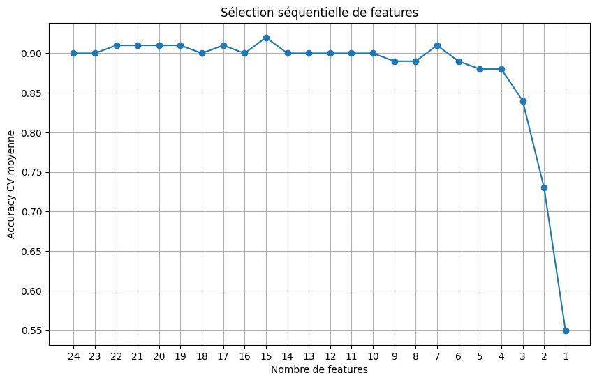

```python
# Conversion des résultats en DataFrame et tri par nombre de features décroissant
results_df = pd.DataFrame(results)
results_df = results_df.sort_values(by="n_features", ascending=False)

plt.figure(figsize=(10,6))
plt.plot(results_df["n_features"], results_df["mean_accuracy"], marker="o")
plt.xlabel("Nombre de features")
plt.ylabel("Accuracy CV moyenne")
plt.title("Sélection séquentielle de features")
plt.gca().invert_xaxis()  # inverser l'axe car le nb de features décroît
plt.xticks(results_df["n_features"])
plt.grid()
plt.show()
```

On observe un maximum avec 15 features, supérieur d'un pourcent aux autres configurations.

On va donc tenter de prendre cette ensemble de features, faire une prédiction sur le test et réaliser une soumission Kaggle. On utilise la dataframe ci dessous qui récapitule les features supprimées à chaque fois pour établir la liste des features à conserver.

```python
results_df.reset_index(drop=True, inplace=True)
results_df.head(24)
```

|  | n_features | feature_removed | mean_accuracy |
| --- | --- | --- | --- |
| 0 | 24 | weight | 0.90 |
| 1 | 23 | bsa | 0.90 |
| 2 | 22 | height | 0.91 |
| 3 | 21 | volume_RV_ED | 0.91 |
| 4 | 20 | rayon_min | 0.91 |
| 5 | 19 | volume_myocardium_ES | 0.91 |
| 6 | 18 | volume_LV_ED_indexed | 0.90 |
| 7 | 17 | myocardium_mass | 0.91 |
| 8 | 16 | rayon_moy | 0.90 |
| 9 | 15 | myocardium_mass_indexed | 0.92 |
| 10 | 14 | volume_RV_ED_indexed | 0.90 |
| 11 | 13 | volume_LV_ED | 0.90 |
| 12 | 12 | volume_myocardium_ED | 0.90 |
| 13 | 11 | volume_RV_ES | 0.90 |
| 14 | 10 | rayon_max | 0.90 |
| 15 | 9 | volume_RV_ES_indexed | 0.89 |
| 16 | 8 | volume_LV_ES | 0.89 |
| 17 | 7 | FE_RV | 0.91 |
| 18 | 6 | volume_LV_ES_indexed | 0.89 |
| 19 | 5 | ratio_ED_myocardium_LV | 0.88 |
| 20 | 4 | ratio_ED_RV_LV | 0.88 |
| 21 | 3 | ratio_ES_myocardium_LV | 0.84 |
| 22 | 2 | ratio_ES_RV_LV | 0.73 |
| 23 | 1 | [FE_LV] | 0.55 |

```python
selected_features = ['volume_myocardium_ES','rayon_moy','volume_LV_ED_indexed','volume_LV_ED','volume_myocardium_ED',
                    'volume_RV_ES','rayon_max','volume_RV_ES_indexed','volume_LV_ES','FE_RV','volume_LV_ES_indexed',
                    'ratio_ED_myocardium_LV','ratio_ED_RV_LV','ratio_ES_myocardium_LV','ratio_ES_RV_LV','FE_LV']

# on va donc créer un nouveau dataframe avec ces features
df_filtre_train = pd.read_csv("cardiac_features_train.csv")
df_filtre_test = pd.read_csv("cardiac_features_test.csv")
df_filtre_train = df_filtre_train[selected_features + [target_col, 'patient_id']]
df_filtre_test = df_filtre_test[selected_features + ['patient_id']]
```

EN réalisant alors un dernier entrainement et une prédiction, on peut constituer un csv que l'on peu soumettre.

```python
# entrainement final sur nos 15 features
X_train = df_filtre_train.drop(columns=[target_col, 'patient_id'])
y_train = df_filtre_train[target_col]
X_test = df_filtre_test.drop(columns=['patient_id'])
# Normalisation des données
scaler = StandardScaler()
X_train_scaled = scaler.fit_transform(X_train)
X_test_scaled = scaler.transform(X_test)

# Entraînement du modèle sur l'ensemble des données
rf_model = RandomForestClassifier(random_state=random_state, n_jobs=-1, n_estimators=100)
rf_model.fit(X_train_scaled, y_train)
# Prédire sur le jeu de test
y_pred = rf_model.predict(X_test_scaled)

# Sauvegarder les résultats dans un fichier CSV
def save_test_predictions_to_csv(predictions, output_path="predictions_3105_100.csv"):
    df_test = pd.read_csv("cardiac_features_test.csv")
    df_test['prediction'] = predictions
    # il faut renomer la colonne patient_id en Id et prediction en Category
    df_test.rename(columns={'patient_id': 'Id', 'prediction': 'Category'}, inplace=True)
    df_test = df_test[['Id', 'Category']]
    df_test.to_csv(output_path, index=False)
    print(f"Prédictions sauvegardées dans {output_path}")
save_test_predictions_to_csv(y_pred, output_path="output/predictions_0104_100_15features.csv")
```

```
Prédictions sauvegardées dans output/predictions_0104_100_15features.csv
```

Si on affiche la répartition de nos prédictions, on obtient quelque chose d'équilibré !

C'est donc mieux ! Néanmoins, notre accuracy à l'entrainement est de 92%. Il est donc peu probable qu'on atteigne 100% par un coup de baguette magique, et il est fort probable que notre modèle inverse des patients, et si on doit s'en réferer à ce qu'on a vu depuis le début il est probable que cela soit entre les classes 1 et 2 majoritairement.

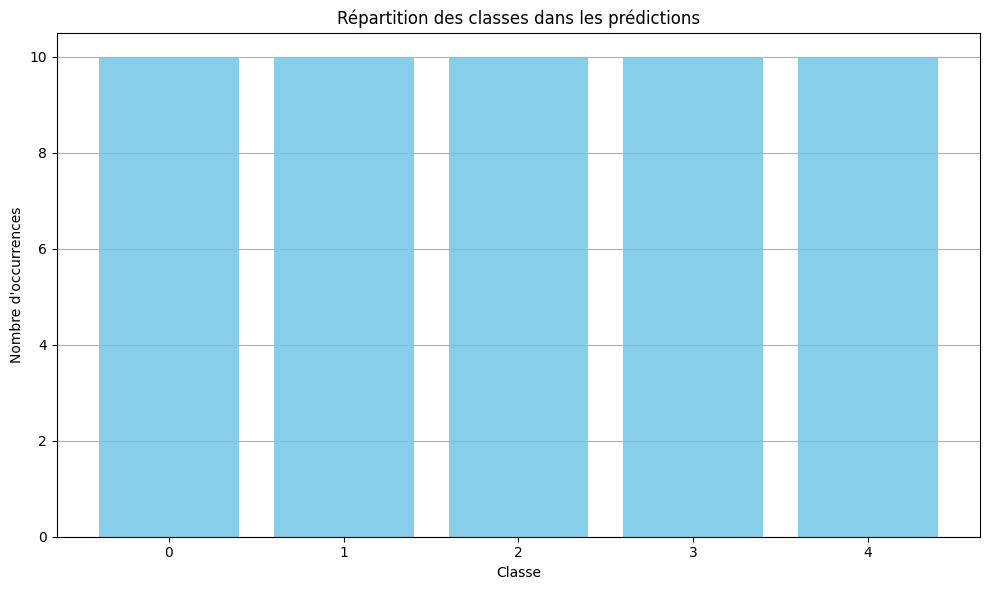

```python
class_counts = pd.Series(y_pred).value_counts().sort_index()
class_counts_df = pd.DataFrame({'Classe': class_counts.index, 'Nombre': class_counts.values})
plt.figure(figsize=(10, 6))
plt.bar(class_counts_df['Classe'], class_counts_df['Nombre'], color='skyblue')
plt.title("Répartition des classes dans les prédictions")
plt.xlabel("Classe")
plt.ylabel("Nombre d'occurrences")
plt.xticks(class_counts_df['Classe'])
plt.grid(axis='y')
plt.tight_layout()
plt.show()
```

En publiant cette solution on obtient 1 sur le public !

C'est une bonne nouvelle, signe qu'on a amélioré notre modèle. Néanmoins cela signifie aussi que désormais il sera compliqué de savoir si notre modèle est amélioré ou pas.

Après la fin du challenge, on observe que ce modèle score 88% sur le private, ce qui en fait l'un des meilleurs soumissions du challenge.

## 6. Tentatives d'améliorations successives

Avec une baseline solide, nous pouvons désormais tenter d'améliorer notre modèle. On propose donc des améliorations successives qui ont étées pensé au fil du projet.

### 6.1 Optimisation bayésienne

Une démarche classique en machine learning consiste à rechercher les paramètres optimaux. Pour cela plusieurs méthodes sont possibles :

- **Grid Search**, où l'on liste l'ensemble des paramètres que l'on désire tester. On réalise alors un entrainement pour chacune combinaison possible. C'est une méthode qui peut devenir très couteuse très rapidement, surtout si l'on désire tester de nombreuses combinaisons.
- **Random Serach**. On teste tous les hyper-paramètres mais aléatoirement (sauf à arreter avant la fin)
- **Bayesian Search**. On recherche alors de manière plus intelligente, en choisissant la prochaine combinaison de paramètres selon un modèle probabilistique. La recherche se fait alors de la manière suivante :
  1. *Initialisation*: On démarre avec des paramètres initiaux choisis à la main.
  2. *Construire un modèle de substitution*: On fit un modèle de substitution (probabiliste) chargé de prédire les performances à partir des entrainements précedents.
  3. *Prochains paramètres* On détermine alors le prochain ensemble d'hyper-paramètres à tester.
  4. *Convergence*: En itérant cela, on espère converger vers un ensemble d'hyper-paramètres en un nombre d'itérations bien réduit par rapport aux autres méthodes.

Pour l'implémentation on utilisera **Optuna** qui réalise cette optimisation. On observera les performances à l'issue de cet entrainement.

Etant donné que l'entrainement d'un Random Forest est depuis le début, relativement rapide, on fait cette recherche aussi sur les features utilisées ! Cette méthode est certe un peu bourrin, mais on verra si elle nous permet d'améliorer nos performances.

```python
from skopt import BayesSearchCV
from skopt.space import Integer, Categorical
from sklearn.model_selection import StratifiedKFold
from sklearn.ensemble import RandomForestClassifier
from sklearn.feature_selection import SelectKBest, f_classif
from sklearn.pipeline import Pipeline
import warnings

cv_strategy = StratifiedKFold(n_splits=5, shuffle=True, random_state=12)
scoring_metric = 'accuracy'
```

On recharge les données d'entrainement, et on vérifie leur intégrité rapidement.

```python
# chargeons les données d'entraînement
df_train_full = pd.read_csv("cardiac_features_train.csv")
feature_columns = df_train_full.columns[1:-1]
X_full = df_train_full[feature_columns]
y_full = df_train_full.iloc[:, -1]
feature_names_full = X_full.columns.tolist()
n_features_total = X_full.shape[1]
print(f"Données d'entraînement chargées: {X_full.shape}, {y_full.shape}")
print(f"Nombre total de features initiales: {n_features_total}")
```

```
Données d'entraînement chargées: (100, 24), (100,)
Nombre total de features initiales: 24
```

On réalise notre entrainement comme mentionné plus haut. Quelques détails :

- On se doute que la meilleur configurations ne se trouvera pas avec 3 features par exemple. On peut donc fixer une borne minimale au nombre de features.
- Si on trouve une configuration avec la même performance, on choisit celle avec le plus petit nombre de features pour minimiser l'overfitting.

```python
overall_best_score = -np.inf
best_initial_feature_count = 0
best_params_overall = None
best_pipeline_overall = None
selected_features_for_best_pipeline = None

min_features_to_test = 10
for n_initial_features in range(n_features_total, min_features_to_test - 1, -1):
    print(f"\n===== Test avec les {n_initial_features} meilleures features =====")

    pre_selector = SelectKBest(score_func=f_classif, k=n_initial_features)
    pre_selector.fit(X_full, y_full)
    selected_indices = pre_selector.get_support(indices=True)
    current_feature_names = X_full.columns[selected_indices].tolist()

    X_current = X_full.iloc[:, selected_indices]

    pipeline_rf_loop = Pipeline([
        ('selector', SelectKBest(score_func=f_classif)),
        ('classifier', RandomForestClassifier(random_state=42, class_weight='balanced'))
    ])

    search_spaces_rf_loop = {'selector__k': Integer(5, n_initial_features),'classifier__n_estimators': Integer(50, 500),
                             'classifier__max_depth': Integer(3, 50),'classifier__min_samples_split': Integer(2, 100),
                             'classifier__min_samples_leaf': Integer(1, 50),
                             'classifier__max_features': Categorical(['sqrt', 'log2', 0.1, 0.3, 0.5, 0.7, 0.9])}

    bayes_search_rf_loop = BayesSearchCV(estimator=pipeline_rf_loop,search_spaces=search_spaces_rf_loop,n_iter=25,
                                         cv=cv_strategy,scoring=scoring_metric,n_jobs=-1,random_state=42,verbose=0)

    # Entraînement du modèle avec la recherche bayésienne
    bayes_search_rf_loop.fit(X_current, y_full)

    current_best_score = bayes_search_rf_loop.best_score_
    print(f"Accuracy pour {n_initial_features} features : {current_best_score:.4f}")
    print(f"Meilleurs hyper-paramètres : {bayes_search_rf_loop.best_params_}")

    if current_best_score > overall_best_score:
        overall_best_score = current_best_score
        best_initial_feature_count = n_initial_features
        best_params_overall = bayes_search_rf_loop.best_params_
        best_pipeline_overall = bayes_search_rf_loop.best_estimator_
        selected_features_for_best_pipeline = current_feature_names
        print(f"====== Nouvelle meilleure configuration globale trouvée ! ======")

print("\n====== Recherche Globale Terminée ======")
print(f"Best Accuracy en CV : {overall_best_score:.3f}")
print(f"Nombre optimal de features : {best_initial_feature_count}")
print(f"Meilleurs hyperparamètres correspondants: {best_params_overall}")
print(f"Features utilisées pour entraîner ce meilleur pipeline ({len(selected_features_for_best_pipeline)}):")
print(selected_features_for_best_pipeline)
```

[output not shown]

[output cut: 16 more lines]

[output not shown]

Sur le train, 92% semble correct, mais pas d'une grande amélioration par rapport à ce qu'on faisait précedemment.

Néanmoins, quand on poste la soummission sur Kaggle, on obtient un résultat de :

- 1.0 sur le public. C'est bien !
- 85% sur le private ... c'est moins bien qu'avec un Random Forest non optimisé ! Ainsi, on réalise un sur-apprentissage, qui amène a de moins bonne performance pour généraliser.

Cette conclusion n'était pas visible lors du challenge puisqu'on avait pas accès au private et que nos deux derniers modèles étaient tous les deux à 1.

```python
print("\n--- Prédiction sur le jeu de test et Sauvegarde ---")
df_test = pd.read_csv("cardiac_features_test.csv")
X_test_full = df_test.drop(columns=[df_test.columns[0]]) # Exclure la colonne ID
test_ids = df_test.iloc[:, 0].astype(int) # Garder les IDs
print(f"Données de test chargées: {X_test_full.shape}")

if best_pipeline_overall is not None and selected_features_for_best_pipeline is not None:
    X_test_selected = X_test_full.reindex(columns=selected_features_for_best_pipeline, fill_value=0)
    y_pred_test = best_pipeline_overall.predict(X_test_selected)
    submission_df = pd.DataFrame({'Id': test_ids, 'Category': y_pred_test})
    output_dir, output_filename = "output", "prediction_rf_bayes_optimized.csv"
    output_path = os.path.join(output_dir, output_filename)
    os.makedirs(output_dir, exist_ok=True)
    submission_df.to_csv(output_path, index=False)
    print(f"Prédictions sauvegardées dans : {output_path}")

nb=10
print(f"\nAperçu des {nb} premières prédictions :")
submission_df.head(nb)
```

```
--- Prédiction sur le jeu de test et Sauvegarde ---
Données de test chargées: (50, 24)
Prédictions sauvegardées dans : output/prediction_rf_bayes_optimized.csv

Aperçu des 10 premières prédictions :
```

|  | Id | Category |
| --- | --- | --- |
| 0 | 101 | 3 |
| 1 | 102 | 4 |
| 2 | 103 | 3 |
| 3 | 104 | 3 |
| 4 | 105 | 2 |
| 5 | 106 | 1 |
| 6 | 107 | 4 |
| 7 | 108 | 2 |
| 8 | 109 | 1 |
| 9 | 110 | 0 |

### 6.2 SMOTE (Synthetic Minority Over-sampling Technique)

Le problème principal que nous devons régler est un overfitting, en partie du à un faible nombre de données.

J'ai alors eu l'idée d'utiliser SMOTE, pour créer artificiellement de la donnée. Ce dernier génère de nouvelles observations artificielles à partir d’interpolations qui, contrairement à une simple duplication, sont des points synthétiques réalistes.

```python
from imblearn.over_sampling import SMOTE

print(f"Distribution avant SMOTE : {np.bincount(y_full)}")
target_samples_per_class = 40
unique_classes = np.unique(y_full)
sampling_strategy_dict = {cls: target_samples_per_class for cls in unique_classes}
smote = SMOTE(random_state=42, sampling_strategy=sampling_strategy_dict, k_neighbors=5)
X_smote, y_smote = smote.fit_resample(X_full, y_full)
print(f"Distribution après SMOTE : {np.bincount(y_smote)}")
```

```
Distribution avant SMOTE : [20 20 20 20 20]
Distribution après SMOTE : [40 40 40 40 40]
```

On est passé de 20 patients par classe, à 40 patients par classe.

En entrainant un Random Forest sur ces nouvelles données, on obtient 97% d'accuracy ! C'est extrèmement haut, mais à aborder avec beaucoup de précautions puisqu'on se doute que cela va overfitter.

```python
rf_smote = RandomForestClassifier(random_state=random_state, n_jobs=-1, n_estimators=100)
cv_smote = StratifiedKFold(n_splits=5, shuffle=True, random_state=42)
scaler_smote = StandardScaler()
X_smote_scaled = scaler_smote.fit_transform(X_smote)
scores_smote = cross_val_score(rf_smote, X_smote_scaled, y_smote, cv=cv_smote, scoring='accuracy')
print(f"Performance RF après SMOTE (moyenne 5-fold CV) : {scores_smote.mean():.4f} ± {scores_smote.std():.4f}")
```

```
Performance RF après SMOTE (moyenne 5-fold CV) : 0.9700 ± 0.0187
```

Réalisons un fit sur les nouvelles données SMOTE, et réalisons une prédiction.

```python
X_test_full_scaled = scaler_smote.transform(X_test_full)
rf_smote.fit(X_smote_scaled, y_smote)
y_pred_smote = rf_smote.predict(X_test_full_scaled)
submission_df_smote = pd.DataFrame({'Id': test_ids, 'Category': y_pred_smote})
output_dir, output_filename = "output", "prediction_rf_smote.csv" # Renamed file for clarity
output_path = os.path.join(output_dir, output_filename)
os.makedirs(output_dir, exist_ok=True)
submission_df_smote.to_csv(output_path, index=False)
print(f"Prédictions sauvegardées dans : {output_path}")
```

```
Prédictions sauvegardées dans : output/prediction_rf_smote.csv
```

En effet, la soumission que nous réalisons atteint 93% sur le public, et 82% sur le private.

C'est donc un exemple clair d'overfitting. Ajouter des données artificiellement peut fonctionner si on doit ré-équilibrer des classes, mais sinon ce n'est visiblement pas une idée formidable.

### 6.3 XGBoost

Jusqu'a présent on s'est contenté de tester des Randoms Forest. Or dans la plupart des compétitions de Machine Learning sur de la donnée tabulaire, XGBoost est le meilleur modèle pour parvenir à de bonnes performances grace à sa capacité à capturer efficacement les interactions non linéaires entre les caractéristiques.

De plus, il intègre une régularisation (contrôle de la complexité des arbres, pénalisation L1/L2) limitant le risque de surapprentissage, particulièrement important dans notre cas.

C'est donc tout naturellement que j'ai testé d'en implémenter un.

```python
import xgboost as xgb
from sklearn.pipeline import Pipeline
from sklearn.preprocessing import StandardScaler
from sklearn.model_selection import cross_val_score
import numpy as np
import os
import pandas as pd

xgb_model = xgb.XGBClassifier(objective='multi:softmax',num_class=len(np.unique(y_full)), eval_metric='merror',
                                random_state=random_state, n_estimators=100, learning_rate=0.05,
                                max_depth=4, subsample=0.8, colsample_bytree=0.8, reg_alpha=0.2, reg_lambda=1)
pipeline_xgb = Pipeline([
    ('scaler', StandardScaler()),
    ('classifier', xgb_model)
])
xgb_cv_scores = cross_val_score(pipeline_xgb, X_full, y_full, cv=cv_strategy, scoring=scoring_metric, n_jobs=-1)
print(f"XGBoost Performance (moyenne {cv_strategy.get_n_splits()}-fold CV): {xgb_cv_scores.mean():.4f} ± {xgb_cv_scores.std():.4f}")
```

```
XGBoost Performance (moyenne 5-fold CV): 0.8900 ± 0.0735
```

```python
# search for best hyperparameters
search_spaces_xgb = {
    'classifier__n_estimators': Integer(50, 500),
    'classifier__max_depth': Integer(3, 10),
    'classifier__learning_rate': (0.01, 0.1, 0.2),
    'classifier__subsample': (0.5, 0.8, 1.0),
    'classifier__colsample_bytree': (0.5, 0.8, 1.0),
    'classifier__reg_alpha': (0, 1e-2, 1e-1),
    'classifier__reg_lambda': (1e-2, 1e-1, 1)
}
bayes_search_xgb = BayesSearchCV(estimator=pipeline_xgb, search_spaces=search_spaces_xgb, n_iter=25,
                                 cv=cv_strategy, scoring=scoring_metric, n_jobs=-1, random_state=random_state, verbose=0)
bayes_search_xgb.fit(X_full, y_full)
best_xgb_score = bayes_search_xgb.best_score_
best_xgb_params = bayes_search_xgb.best_params_
print(f"Meilleur score XGBoost : {best_xgb_score:.4f}")
print(f"Meilleurs hyper-paramètres XGBoost : {best_xgb_params}")
```

```
Meilleur score XGBoost : 0.9100
Meilleurs hyper-paramètres XGBoost : OrderedDict([('classifier__colsample_bytree', 0.8), ('classifier__learning_rate', 0.01), ('classifier__max_depth', 4), ('classifier__n_estimators', 95), ('classifier__reg_alpha', 0), ('classifier__reg_lambda', 1), ('classifier__subsample', 0.8)])
```

```python
pipeline_xgb.fit(X_full, y_full)
X_test_xgb = df_test.drop(columns=['patient_id'])
y_pred_xgb_test = pipeline_xgb.predict(X_test_xgb)
submission_df_xgb = pd.DataFrame({'Id': test_ids, 'Category': y_pred_xgb_test})
output_path_xgb = os.path.join("output", "prediction_xgb.csv")
submission_df_xgb.to_csv(output_path_xgb, index=False)
print(f"XGBoost prédictions sauvegardées dans : {output_path_xgb}")
```

```
XGBoost prédictions sauvegardées dans : output/prediction_xgb.csv
```

Mais avec ou sans optimisation, je n'arrive pas à dépasser 91%, et les performances sur le dataset test sont très inférieures à notre meilleur modèle (82% sur le private).

Cette essai nous a permis de tirer un enseignement précieux : sur un petit jeux de données fortement structurés, les méthodes plus simples (Random Forest) sont parfois tout aussi efficaces, voire supérieures à des méthodes plus sophistiquées (XGBoost), tout en étant plus faciles à interpréter.

## 7. Modèle de Deep Learning

Depuis le début du projet les méthodes envisagées ont été Random Forest et XG Boost.

Et pour cause : sur de la données tabulaire le deep learning ne parvient pas à égaler ces modèles.

Néanmoins en janvier 2025 sort un papier de recherche intitulé :

**TABPFN: A TRANSFORMER THAT SOLVES SMALL TABULAR CLASSIFICATION PROBLEMS IN A SECOND**

J'ai donc cherché à implémenter ce papier de recherche, en ésperant obtenir une amélioration non négligeable.

### 7.1 Principes clés

TabPFN repose sur deux idées fondamentales:

1. **Apprentissage in-context**:
   - Le modèle ne réentraîne pas ses poids pour un nouveau jeu de données.
   - Il apprend **à apprendre** en observant directement des exemples d’entrée-sortie, et prédit pour de nouvelles instances dans la même passe.
2. **Inférence bayésienne approximée par un Transformer pré-entraîné** :
   - Un transformer à été entraîné une fois, en offline, sur **des millions de jeux synthétiques**.
   - Ce pré-entraînement permet d’approximer la **posterior predictive distribution (PPD)** pour tout nouveau dataset réel, avec une très bonne généralisation.

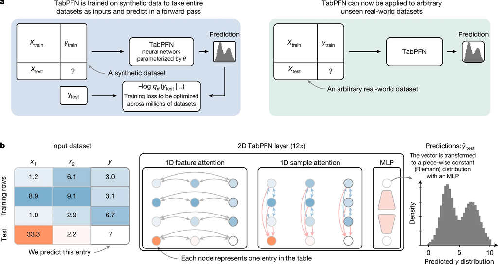

```python
from IPython.display import Image, display
display(Image(filename='TabPFN.png', width=1000))
```

### 7.2 Implémentation

Pourquoi attendre de bonnes performances ici ? A priori, notre challenge est parfaitement adapté à son utilisation:

- Dataset très petit
- Caractéristiques purement numériques, sans valeurs manquantes.
- Peu de classes.

```python
# j'ai trouvé un papier publié récemment, qui propose un nouveau reseau de neurones spétialement pour les tabular data de petite taille
# c'est tabPFN, essayons de l'utiliser pour avoir une baseline avec cette méthode
from sklearn.model_selection import KFold, cross_val_score  # pour la validation croisée
from tabpfn_extensions.rf_pfn import RandomForestTabPFNClassifier
from tabpfn_extensions import TabPFNClassifier  # modèle de base TabPFN

df_train_tabpfn = pd.read_csv("cardiac_features_train.csv")
df_test_tabpfn = pd.read_csv("cardiac_features_test.csv")

df_train_tabpfn = df_train_tabpfn[selected_features + [target_col, 'patient_id']]
df_test_tabpfn = df_test_tabpfn[selected_features + ['patient_id']]

X_train = df_train_tabpfn.drop(columns=[target_col, 'patient_id'])
y_train = df_train_tabpfn[target_col]
X_test = df_test_tabpfn.drop(columns=['patient_id'])
# Normalisation des données
scaler = StandardScaler()
X_train_scaled = scaler.fit_transform(X_train)
X_test_scaled = scaler.transform(X_test)
```

```python
# modèle TabPFN de base
clf_base = TabPFNClassifier()
tabpfn_tree_clf = RandomForestTabPFNClassifier(tabpfn=clf_base,verbose=1,max_predict_time=60,
                                               fit_nodes=True,adaptive_tree=True)
# on avait fait une cross val sur le rf, faisons pareil pour comparer des choux avec des choux
cv = KFold(n_splits=5, shuffle=True, random_state=10)
scores = cross_val_score(tabpfn_tree_clf, X_train_scaled,y_train, cv=cv, scoring='accuracy', verbose=1)

print("Cross-validation scores:", scores)
print("Accuracy:", np.mean(scores), "+/-", np.std(scores))
```

```
Cross-validation scores: [0.8  0.95 0.85 1.   0.95]
Accuracy: 0.9099999999999999 +/- 0.07348469228349533
```

```
Prédictions sauvegardées dans output/predictions_0204_tabpfn.csv
```

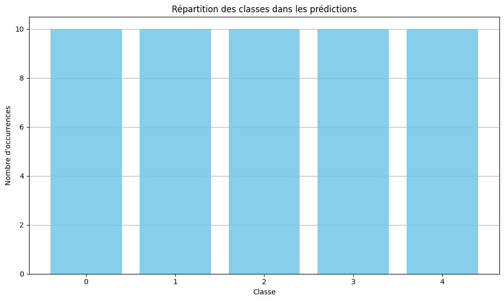

```python
#Lets make a prediction on the test set
tabpfn_tree_clf.fit(X_train_scaled, y_train)
y_pred = tabpfn_tree_clf.predict(X_test_scaled)
save_test_predictions_to_csv(y_pred, output_path="output/predictions_0204_tabpfn.csv")

class_counts = pd.Series(y_pred).value_counts().sort_index()
class_counts_df = pd.DataFrame({'Classe': class_counts.index, 'Nombre': class_counts.values})
plt.figure(figsize=(10, 6))
plt.bar(class_counts_df['Classe'], class_counts_df['Nombre'], color='skyblue')
plt.title("Répartition des classes dans les prédictions")
plt.xlabel("Classe")
plt.ylabel("Nombre d'occurrences")
plt.xticks(class_counts_df['Classe'])
plt.grid(axis='y')
plt.tight_layout()
plt.show()
```

Malgré ses promesses, **TabPFN ne surpasse pas toujours les modèles classiques**. Dans notre projet :

- Il plafonne autour de **91 %** en validation croisée, ce qui reste en-dessous de notre Random Forest optimisé.
- Il réalise 86% sur le public, mais 88% sur le private ! Ce qui signifie que au moins, il n'overfit pas.
- Son architecture impose un nombre limité d’exemples, pas de valeurs manquantes, etc...

**Enseignement :**

TabPFN semble être un **formidable modèle universel**, avec un excellent compromis performance/temps d'entraînement, surtout quand :

- Le nombre d’échantillons est très faible.
- L’exploration d’architectures complexes n’est pas souhaitée.

Mais il ne remplace pas encore totalement les approches classiques dès que des ajustements fins ou des ensembles sont nécessaires.

### 7.3 AutoTabPFN

On teste rapidement une autre implémentation de TabPFN que le papier propose. Mais elle ne fait pas mieux que précedemment.

```python
from tabpfn_extensions.post_hoc_ensembles.sklearn_interface import AutoTabPFNClassifier

clf = AutoTabPFNClassifier(max_time=60, device="cpu")
clf.fit(X_train_scaled, y_train)
predictions = clf.predict(X_test_scaled)
```

[output not shown]

```python
save_test_predictions_to_csv(predictions, output_path="output/predictions_0204_autotabpfn.csv")
class_counts = pd.Series(y_pred).value_counts().sort_index()
class_counts_df = pd.DataFrame({'Classe': class_counts.index, 'Nombre': class_counts.values})
```

```
Prédictions sauvegardées dans output/predictions_0204_autotabpfn.csv
```

## 8. Confusion récurente entre deux classes

### 8.1 Analyse

Comme on peut le voir, on ne parvient pas à dépasser un plateau en terme de performances.

Pour régler ce problème, tournons motre attention vers les sources d'erreurs. En regardant les matrices de confusion tout au long du projet, on remarque souvent la même chose : **ce sont les classes 1 et 2 qui sont toujours interchangées**.

Pour creuser un peut plus, on essaye d'afficher les distributions de features importantes pour ces deux classes, ainsi qu'un PCA pour réduire à deux dimensions les données sur l'ensemble du jeu de donnée (j'ai en fait utilisé TSNE qui est très similaire, mais qui permettait une plus grande clarté).

```python
y_true_cv, y_pred_cv = np.array(y_test_global), np.array(y_pred_global)
errors_1_2 = ((y_true_cv == 1) & (y_pred_cv == 2)) | ((y_true_cv == 2) & (y_pred_cv == 1))
df_errors_1_2 = features_df[errors_1_2]
print("Patients (train set) confondus entre classe 1 et classe 2 lors de la CV:")
display(df_errors_1_2)
df_errors_1_2.to_csv("output/erreurs_1_2.csv", index=False)
```

```
Patients (train set) confondus entre classe 1 et classe 2 lors de la CV:
```

|  | patient_id | volume_LV_ED | volume_LV_ES | volume_RV_ED | volume_RV_ES | volume_myocardium_ED | volume_myocardium_ES | FE_LV | FE_RV | myocardium_mass | ... | bsa | volume_LV_ED_indexed | volume_LV_ES_indexed | volume_RV_ED_indexed | volume_RV_ES_indexed | myocardium_mass_indexed | rayon_min | rayon_max | rayon_moy | category |
| --- | --- | --- | --- | --- | --- | --- | --- | --- | --- | --- | --- | --- | --- | --- | --- | --- | --- | --- | --- | --- | --- |
| 28 | 029 | 21.479391 | 3.894657 | 15.813738 | 7.206649 | 26.902266 | 26.580267 | 81.867936 | 54.427925 | 28.247379 | ... | 1.584370 | 13.557059 | 2.458175 | 9.981092 | 4.548591 | 17.828782 | 1.00 | 16.50 | 7.675679 | 3 |
| 48 | 049 | 16.611069 | 13.150856 | 6.475762 | 1.773551 | 11.993192 | 13.355300 | 20.830769 | 72.612470 | 12.592852 | ... | 1.839310 | 9.031144 | 7.149887 | 3.520757 | 0.964248 | 6.846510 | 1.00 | 10.25 | 5.824074 | 1 |
| 49 | 050 | 35.573244 | 29.723592 | 12.172081 | 3.347769 | 18.783286 | 22.499055 | 16.443966 | 72.496326 | 19.722451 | ... | 1.601443 | 22.213242 | 18.560504 | 7.600695 | 2.090470 | 12.315424 | 2.00 | 8.50 | 5.077778 | 1 |
| 60 | 061 | 18.785842 | 7.035427 | 23.827940 | 8.727200 | 14.788963 | 15.448295 | 62.549313 | 63.374088 | 15.528411 | ... | 2.207923 | 8.508375 | 3.186445 | 10.792014 | 3.952673 | 7.033039 | 2.35 | 10.50 | 5.748264 | 0 |
| 63 | 064 | 19.512793 | 8.782719 | 26.209276 | 14.401365 | 18.860655 | 23.168988 | 54.989943 | 45.052413 | 19.803688 | ... | 2.122985 | 9.191207 | 4.136967 | 12.345484 | 6.783546 | 9.328229 | 1.30 | 8.80 | 6.055556 | 0 |
| 83 | 084 | 15.486713 | 6.031129 | 37.183444 | 22.131177 | 8.926582 | 11.083478 | 61.056106 | 40.481100 | 9.372911 | ... | 1.170949 | 13.225776 | 5.150632 | 31.754958 | 18.900202 | 8.004541 | 1.00 | 7.45 | 3.292824 | 4 |
| 89 | 090 | 13.848296 | 7.635923 | 38.885697 | 23.260810 | 10.716486 | 11.337154 | 44.860197 | 40.181579 | 11.252310 | ... | 1.611902 | 8.591276 | 4.737213 | 24.124106 | 14.430659 | 6.980765 | 1.15 | 6.55 | 3.511905 | 4 |

7 rows × 26 columns

On peut ainsi tracer nos graphs désirés.

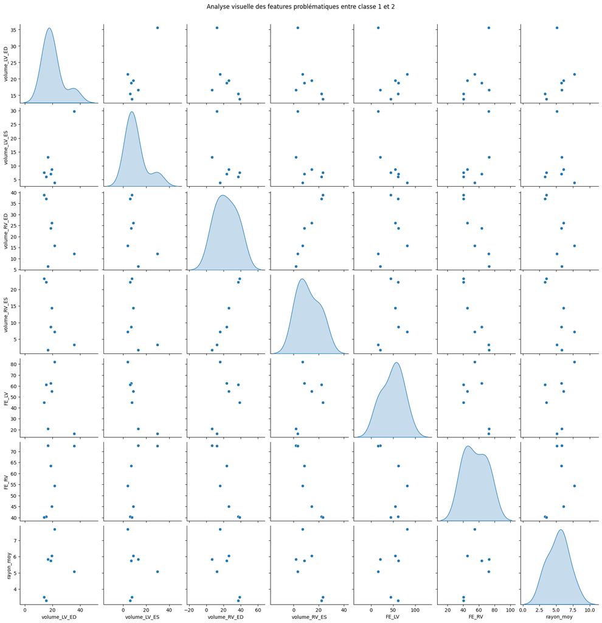

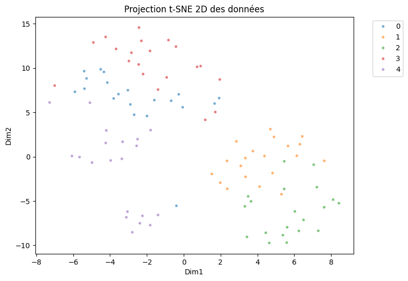

```python
# Pairplot des features clés pour comprendre la confusion du modèle
features_cle = ['volume_LV_ED', 'volume_LV_ES', 'volume_RV_ED',
                'volume_RV_ES','FE_LV', 'FE_RV', 'rayon_moy']
sns.pairplot(df_errors_1_2[features_cle], diag_kind='kde')
plt.suptitle('Analyse visuelle des features problématiques entre classe 1 et 2', y=1.02)
plt.show()

from sklearn.manifold import TSNE
tsne = TSNE(n_components=2, init='pca', random_state=12, perplexity=20)
X_tsne = tsne.fit_transform(X_full)
df_tsne = pd.DataFrame({'Dim1': X_tsne[:, 0],'Dim2': X_tsne[:, 1],
                        'label': y_full})
plt.figure(figsize=(8, 6))
sns.scatterplot(data=df_tsne, x='Dim1', y='Dim2', hue='label', palette='tab10', s=15, alpha=0.6)
plt.title("Projection t-SNE 2D des données")
plt.legend(bbox_to_anchor=(1.05, 1), loc='upper left')
plt.show()
```

### 8.2 Model Stacking

A ce stade, pour aller au-delà des performances d’un seul modèle, la seule idée que j'ai est d'en utiliser plusieurs. Pour cela la première idée est de faire du **Model Stacking**

#### 8.2.1 Principe

Nos observations précédentes ont montré que :

- Le **Random Forest** offrait une bonne robustesse, avec une bonne stabilité en validation croisée.
- **TabPFN**, bien qu’un peu moins performant seul, produisait des prédictions parfois différentes de celles du RF.

Plutôt que de choisir entre les deux, pourquoi pas les **combiner** à travers un modèle de type "méta-classifieur".

Le stacking consiste à :

1. **Niveau 1 – modèles de base** : entraîner plusieurs modèles indépendants (ici, Random Forest et TabPFN) sur les mêmes données. Chacun prédit une probabilité pour chaque classe.
2. **Niveau 2 – méta-modèle** : un modèle final (ici une régression logistique) est entraîné à partir des **sorties des modèles de base**, pour apprendre à combiner leurs prédictions de façon optimale.

#### 8.2.2 Implémentation avec OOF

Un stacking naïf entraîne un fort risque de fuite de données si les modèles de base sont entraînés et testés sur les mêmes échantillons. Pour éviter cela, on utilise une stratégie de **prédiction OOF (out-of-fold)** :

- On réalise une CV pour chaque modèle de base.
- Pour chaque fold, on fait des prédictions uniquement sur les données de validation (non vues à l'entraînement).
- Ces prédictions sont utilisées comme entrées pour entraîner le méta-modèle.

Une fois entraîné, le méta-modèle peut alors être utilisé sur les données de test, après avoir généré les sorties des modèles de base sur l’ensemble de ces données.

```
Accuracy : 0.89
```

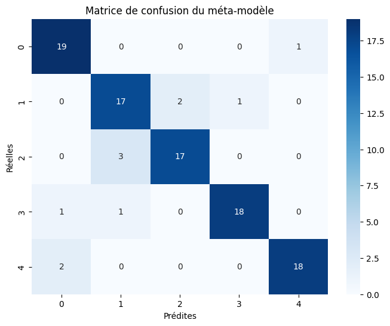

```python
from sklearn.linear_model import LogisticRegression
from sklearn.pipeline import make_pipeline
from sklearn.model_selection import cross_val_predict
import warnings

warnings.filterwarnings("ignore", category=FutureWarning, module="sklearn.linear_model._logistic")
cv_base = StratifiedKFold(n_splits=4, shuffle=True, random_state=12)

rf = RandomForestClassifier(random_state=random_state, n_jobs=-1, n_estimators=100)
oof_rf = cross_val_predict(rf, X, y, cv=cv_base, method="predict_proba")

tabpfn_raw_stack = RandomForestTabPFNClassifier(tabpfn=clf_base,verbose=1,
                                                max_predict_time=60,fit_nodes=True,
                                                adaptive_tree=True)
oof_tpfn = cross_val_predict(tabpfn_raw_stack, X, y, cv=cv_base, method="predict_proba")


stack_features = np.hstack([oof_rf, oof_tpfn])
meta = make_pipeline(
    StandardScaler(),
    LogisticRegression(max_iter=500))

meta_cv = StratifiedKFold(n_splits=5, shuffle=True, random_state=2)
meta_scores = cross_val_predict(meta, stack_features, y, cv=meta_cv, method="predict")

print("Accuracy :", accuracy_score(y, meta_scores))
# Confusion matrix
cm = confusion_matrix(y, meta_scores)
plt.figure(figsize=(8, 6))
sns.heatmap(cm, annot=True, fmt='d', cmap='Blues', xticklabels=np.unique(y), yticklabels=np.unique(y))
plt.title("Matrice de confusion du méta-modèle")
plt.xlabel("Prédites")
plt.ylabel("Réelles")
plt.show()

warnings.filterwarnings("default", category=FutureWarning, module="sklearn.linear_model._logistic")
```

#### 8.2.3 Résultats

Lorsque l'on réalise la soumission sur Kaggle, il atteint $85\%$ sur le leaderboard private.

## 9. Conclusion

Ce projet ne fut pas facile et fut une belle exploration de l'apprentissage automatique dans un contexte contraint. A partir d'un dataset extrêmement réduit, uniquement basé sur des segmentations déjà fournies, il fallait réussir à tirer le maximum de nos données sans perdre en capacité de généralisation.

Notre approche s’est volontairement appuyée sur des **features cliniquement motivées**. En mettant l’accent sur la qualité des données d’entrée plutôt que sur des modèles complexes, nous avons obtenu dès les premières itérations des résultats solides, confirmés par la validation croisée.

Le modèle **Random Forest**, avec des paramètres de base, et un filtrage des features utilisées, s’est révélé être le plus performant. Les tentatives avec des modèles plus sophistiqués, comme **XGBoost** ou **TabPFN**, n’ont pas apporté d'amélioration significative, malgré leur potentiel théorique. Le stacking, testé en fin de pipeline, a confirmé que le Random Forest capturait déjà l’essentiel du signal exploitable dans nos données.

Notre plus grande difficulté a été la **confusion persistante entre les classes 1 et 2** (infarctus vs cardiomyopathie dilatée), difficile à lever même après SMOTE ou analyse approfondie. Ce problème reflète à la fois des limites du modèle, mais aussi peut-être d'une **proximité clinique réelle** entre certains cas de ces deux pathologies.

Enfin, ce projet nous rappelle une leçon précieuse : dans les situations à faible volume de données, **la maîtrise des données et du domaine prime sur la sophistication algorithmique**. Une bonne ingénierie des features, des validations propres et un pipeline clair valent souvent mieux qu’un deep learning mal appliqué.